# The Philadelphia Eviction Early Warning System

A Predictive Model for Proactive Resource Allocation

Authors

Angel Rutherford

Ixchel Ramirez

Tess Vu

Published

December 8, 2025

# EXECUTIVE SUMMARY

Eviction is both a cause and consequence of poverty that destabilizes entire neighborhoods. Currently, city responses to eviction are reactive, with resources like legal aid and rental assistance deployed *after* filing volumes become a crisis. This project develops a Real-Time Operational Tool for the Philadelphia Office of Homeless Services and the Fair Housing Commission. By shifting from reactive to predictive analysis, we enable the city to allocate limited staff to specific census tracts predicted to experience elevated eviction filings in the coming month.

Our Negative Binomial regression model leverages temporal momentum, spatial spillover effects, policy intervention effects, property tax delinquency stress, and American Community Survey socioeconomic indicators to forecast monthly eviction filing counts at the census tract level.

The model demonstrates strong performance with meaningful improvement, and sets the foundation for building up to a practical and usable tool down the line. Using a robust temporal validation strategy (training through 2023, testing on 2024-2025), the model generalizes well to future periods without overfitting. Also stark racial disparities in eviction burden was identified, with Black-majority tracts accounting for disproportionate shares of filings. These findings emphasize the need for equity-centered implementation safeguards to prevent perpetuating existing disparities through algorithmic resource allocation.

# I. EXPLORATORY DATA ANALYSIS (EDA)

## 1. SETUP AND LIBRARY LOADING

```r
library(lubridate)
library(sf)
library(broom)
library(scales)
library(patchwork)
library(viridis)
library(kableExtra)
library(corrplot)
library(zoo)
library(MASS)
library(car)
library(caret)
library(pROC)
library(spdep)
library(tidycensus)
library(httr)
library(jsonlite)
library(glue)
library(stringr)
library(tidyr)
library(tidyverse)
library(dplyr)
library(knitr)

# Override masking.
select <- dplyr::select
filter <- dplyr::filter

# Disable scientific notation.
options(scipen = 999)

# Save figures.
opts_chunk$set(fig.path = "final_figures/", dpi = 300)
```

```r
# Custom color palette for policy periods.
period_colors <- c(
  "Pre-Moratorium" = "#3498DB",
  "Moratorium" = "#27AE60",
  "Post-Moratorium" = "#E67E22"
)

# Custom color palette for racial categories.
racial_colors <- c(
  "Black" = "#E74C3C",
  "White" = "#3498DB",
  "Hispanic" = "#F39C12",
  "Other" = "#9B59B6"
)
```

## 2. DATA LOADING AND INITIAL EXPLORATION

### Monthly Tract-Level Eviction Data

The primary dataset contains monthly eviction filing counts at the census tract level from January 2020 through November 2025.

```r
# Load monthly eviction filings data at census tract level.
df_monthly_raw <- read.csv("data/eviction/philadelphia_monthly_2020_2021.csv")

# Display initial data dimensions.
cat("MONTHLY EVICTION DATA DIMENSIONS\n")
```

```
MONTHLY EVICTION DATA DIMENSIONS
```

```r
cat(sprintf("Rows: %s\n", comma(nrow(df_monthly_raw))))
```

```
Rows: 29,039
```

```r
cat(sprintf("Columns: %d\n", ncol(df_monthly_raw)))
```

```
Columns: 8
```

```r
cat(sprintf("Variables: %s\n", paste(names(df_monthly_raw), collapse = ", ")))
```

```
Variables: type, GEOID, racial_majority, month, filings_2020, filings_avg, filings_avg_prepandemic_baseline, last_updated
```

```r
# Display first rows to understand data structure.
head(df_monthly_raw, 10) %>%
  kable(caption = "Sample of Raw Monthly Eviction Filing Data",
    col.names = c("Type", "GEOID", "Racial  Majority", "Month", "Filings", "Average Filings", "Pre-Pandemic Average Filings", "Last Updated")) %>%
  kable_styling(bootstrap_options = c("striped", "hover", "condensed"))
```

Sample of Raw Monthly Eviction Filing Data

| Type | GEOID | Racial Majority | Month | Filings | Average Filings | Pre-Pandemic Average Filings | Last Updated |
| --- | --- | --- | --- | --- | --- | --- | --- |
| Census Tract | 42101000101 | White | 01/2020 | 0 | 2.5 | 0.75 |  |
| Census Tract | 42101000101 | White | 02/2020 | 0 | 1.5 | 1.00 |  |
| Census Tract | 42101000101 | White | 03/2020 | 0 | 1.5 | 1.00 |  |
| Census Tract | 42101000101 | White | 04/2020 | 0 | 1.0 | 1.75 |  |
| Census Tract | 42101000101 | White | 05/2020 | 0 | 2.0 | 1.75 |  |
| Census Tract | 42101000101 | White | 06/2020 | 0 | 1.0 | 2.00 |  |
| Census Tract | 42101000101 | White | 07/2020 | 0 | 2.5 | 0.50 |  |
| Census Tract | 42101000101 | White | 08/2020 | 1 | 1.5 | 0.75 |  |
| Census Tract | 42101000101 | White | 09/2020 | 2 | 0.0 | 3.50 |  |
| Census Tract | 42101000101 | White | 10/2020 | 2 | 1.5 | 1.50 |  |

### Weekly Tract-Level Eviction Data

Weekly data at the census tract level provides higher-frequency observations for understanding short-term volatility and patterns.

```r
# Load weekly eviction filings data for high-frequency analysis.
df_weekly_raw <- read.csv("data/eviction/philadelphia_weekly_2020_2021.csv")

# Display weekly data dimensions.
cat("WEEKLY EVICTION DATA DIMENSIONS\n")
```

```
WEEKLY EVICTION DATA DIMENSIONS
```

```r
cat(sprintf("Rows: %s\n", comma(nrow(df_weekly_raw))))
```

```
Rows: 125,563
```

```r
cat(sprintf("Columns: %d\n", ncol(df_weekly_raw)))
```

```
Columns: 9
```

```r
# Display sample of weekly data.
head(df_weekly_raw, 10) %>%
  kable(caption = "Sample of Raw Weekly Eviction Filing Data",
    col.names = c("Type", "GEOID", "Racial  Majority", "Week", "Date", "Filings", "Average Filings", "Pre-Pandemic Average Filings", "Last Updated")) %>%
  kable_styling(bootstrap_options = c("striped", "hover", "condensed"))
```

Sample of Raw Weekly Eviction Filing Data

| Type | GEOID | Racial Majority | Week | Date | Filings | Average Filings | Pre-Pandemic Average Filings | Last Updated |
| --- | --- | --- | --- | --- | --- | --- | --- | --- |
| Census Tract | 42101000101 | White | 1 | 2019-12-29 | 0 | 0.5 | 0.00 | 2025-11-15 |
| Census Tract | 42101000101 | White | 2 | 2020-01-05 | 0 | 0.5 | 0.25 | 2025-11-15 |
| Census Tract | 42101000101 | White | 3 | 2020-01-12 | 0 | 0.5 | 0.25 | 2025-11-15 |
| Census Tract | 42101000101 | White | 4 | 2020-01-19 | 0 | 1.0 | 0.00 | 2025-11-15 |
| Census Tract | 42101000101 | White | 5 | 2020-01-26 | 0 | 0.0 | 0.25 | 2025-11-15 |
| Census Tract | 42101000101 | White | 6 | 2020-02-02 | 0 | 0.0 | 0.25 | 2025-11-15 |
| Census Tract | 42101000101 | White | 7 | 2020-02-09 | 0 | 0.5 | 0.50 | 2025-11-15 |
| Census Tract | 42101000101 | White | 8 | 2020-02-16 | 0 | 0.0 | 0.00 | 2025-11-15 |
| Census Tract | 42101000101 | White | 9 | 2020-02-23 | 0 | 1.0 | 0.25 | 2025-11-15 |
| Census Tract | 42101000101 | White | 10 | 2020-03-01 | 0 | 0.0 | 0.25 | 2025-11-15 |

### Claims Data

The claims dataset has monthly resolution showing the financial severity of eviction cases through median claim amounts, adding political and social context.

```r
# Load aggregated monthly claims data showing financial severity.
df_claims_raw <- read.csv("data/eviction/philadelphia_claims_monthly.csv")

# Display claims data dimensions.
cat("CLAIMS DATA DIMENSIONS\n")
```

```
CLAIMS DATA DIMENSIONS
```

```r
cat(sprintf("Rows: %s\n", comma(nrow(df_claims_raw))))
```

```
Rows: 70
```

```r
cat(sprintf("Columns: %d\n", ncol(df_claims_raw)))
```

```
Columns: 6
```

```r
# Display claims data structure.
head(df_claims_raw, 10) %>%
  kable(digits = 2, caption = "Sample of Monthly Claims Severity Data",
    col.names = c("Date", "Median Claim", "Below $1,000", "Below Median Rent", "Over Six Months Rent", "Baseline Median Claim")) %>%
  kable_styling(bootstrap_options = c("striped", "hover", "condensed"))
```

Sample of Monthly Claims Severity Data

| Date | Median Claim | Below $1,000 | Below Median Rent | Over Six Months Rent | Baseline Median Claim |
| --- | --- | --- | --- | --- | --- |
| 2020-01-01 | 1958.00 | 0.03 | 0.06 | 0.14 | 4200 |
| 2020-02-01 | 1944.00 | 0.03 | 0.06 | 0.14 | 4200 |
| 2020-03-01 | 2050.00 | 0.03 | 0.06 | 0.14 | 4200 |
| 2020-04-01 | NA | NA | NA | NA | 4200 |
| 2020-05-01 | NA | NA | NA | NA | 4200 |
| 2020-06-01 | NA | NA | NA | NA | 4200 |
| 2020-07-01 | 3975.00 | 0.03 | 0.06 | 0.14 | 4200 |
| 2020-08-01 | 3285.31 | 0.03 | 0.06 | 0.14 | 4200 |
| 2020-09-01 | 3639.32 | 0.03 | 0.06 | 0.14 | 4200 |
| 2020-10-01 | 3422.50 | 0.03 | 0.06 | 0.14 | 4200 |

This is not used in the dataset, but for exploration behind the scenes of evictions. It looks like 3% of claims are for below $1,000, which could reflect unpaid fees rather than market rate rent. However, it *could* reflect rent in subsidized public housing. 6% is for the median market rate rents. 14% is for rent unpaid for at least 6 months. These timelines could have varying reasons, especially due to the time-consuming legal aspect that could delay filings.

### Real Estate Tax Balances

Tax delinquency is a proxy for landlord financial stress at the tract level. Properties with outstanding tax balances may pressure landlords to pursue evictions.

```r
# Load real estate tax balances aggregated by census tract.
df_tax_raw <- read.csv("data/eviction/real_estate_tax_balances_census_tract.csv")

# Display tax data dimensions.
cat("TAX DELINQUENCY DATA DIMENSIONS\n")
```

```
TAX DELINQUENCY DATA DIMENSIONS
```

```r
cat(sprintf("Rows: %s\n", comma(nrow(df_tax_raw))))
```

```
Rows: 402
```

```r
cat(sprintf("Columns: %d\n", ncol(df_tax_raw)))
```

```
Columns: 11
```

```r
cat(sprintf("Variables: %s\n", paste(names(df_tax_raw), collapse = ", ")))
```

```
Variables: objectid, census_tract, num_props, min_period, max_period, principal, interest, penalty, other, balance, avg_balance
```

```r
# Display sample of tax delinquency data.
head(df_tax_raw, 10) %>%
  kable(digits = 2, caption = "Sample of Real Estate Tax Balances by Census Tract",
    col.names = c("Object ID", "Census Tract", "Properties", "Minimum Period", "Maximum Period", "Principal", "Interest", "Penalty", "Other", "Balance", "Average Balance")) %>%
  kable_styling(bootstrap_options = c("striped", "hover", "condensed"))
```

Sample of Real Estate Tax Balances by Census Tract

| Object ID | Census Tract | Properties | Minimum Period | Maximum Period | Principal | Interest | Penalty | Other | Balance | Average Balance |
| --- | --- | --- | --- | --- | --- | --- | --- | --- | --- | --- |
| 1 | 42101000101 | 74 | 1985 | 2025 | 1064210.8 | 155230.30 | 29017.78 | 32204.00 | 1280662.9 | 17306.26 |
| 2 | 42101000102 | 144 | 1978 | 2025 | 902561.4 | 162841.03 | 15843.21 | 65842.76 | 1147088.4 | 7965.89 |
| 3 | 42101000200 | 62 | 2007 | 2025 | 1178299.6 | 158347.04 | 52879.01 | 54369.75 | 1443895.4 | 23288.64 |
| 4 | 42101000300 | 38 | 1982 | 2025 | 1160409.9 | 204199.86 | 53290.48 | 10210.36 | 1428110.6 | 37581.86 |
| 5 | 42101000401 | 110 | 1986 | 2025 | 875019.7 | 101247.26 | 26525.82 | 14006.92 | 1016799.7 | 9243.63 |
| 6 | 42101000403 | 23 | 2017 | 2025 | 324383.0 | 47260.28 | 8921.37 | 20065.11 | 400629.8 | 17418.69 |
| 7 | 42101000404 | 12 | 2020 | 2025 | 187919.8 | 29479.15 | 4030.51 | 2819.58 | 224249.1 | 18687.42 |
| 8 | 42101000500 | 19 | 1978 | 2025 | 323535.4 | 76752.47 | 4661.40 | 14405.20 | 419354.5 | 22071.29 |
| 9 | 42101000600 | 23 | 2020 | 2025 | 552582.2 | 76400.67 | 25171.38 | 20471.78 | 674626.1 | 29331.57 |
| 10 | 42101000701 | 29 | 2022 | 2025 | 193651.5 | 21334.13 | 3937.60 | 6824.62 | 225747.8 | 7784.41 |

### Philadelphia Census Tract Geometry

Load Pennsylvania census tracts and filter to Philadelphia County (FIPS 42101) for spatial analysis.

```r
# Load Pennsylvania census tracts shapefile.
pa_tracts_sf <- st_read("data/pa_tracts/pa_tracts.shp", quiet = TRUE)

# Filter to Philadelphia County only using FIPS code 42101.
philly_tracts_sf <- pa_tracts_sf %>%
  filter(str_starts(GEOID, "42101"))

# Display spatial data summary.
cat("PHILADELPHIA CENSUS TRACT GEOMETRY\n")
```

```
PHILADELPHIA CENSUS TRACT GEOMETRY
```

```r
cat(sprintf("Total Philadelphia Tracts: %d\n", nrow(philly_tracts_sf)))
```

```
Total Philadelphia Tracts: 408
```

```r
cat(sprintf("Coordinate Reference System: %s\n", st_crs(philly_tracts_sf)$input))
```

```
Coordinate Reference System: NAD83
```

## 3. DATA CLEANING AND FEATURE ENGINEERING

### Monthly Eviction Data Preparation

```r
# Clean and prepare monthly data with temporal and policy features.
df_monthly <- df_monthly_raw %>%
  # Rename filings variable for clarity.
  rename(filings_count = filings_2020) %>%
  # Parse month string to proper date format.
  mutate(
    date = as.Date(paste0("01/", month), format = "%d/%m/%Y"),
    year = year(date),
    month_num = month(date),
    month_name = month(date, label = TRUE, abbr = FALSE)
  ) %>%
  # Filter out rows with invalid dates.
  filter(!is.na(date)) %>%
  # Convert GEOID to character for joining operations.
  mutate(GEOID = as.character(GEOID)) %>%
  # Create policy intervention indicator for eviction moratorium period.
  mutate(
    moratorium_active = ifelse(
      date >= as.Date("2020-03-01") & date <= as.Date("2021-09-30"),
      1,
      0
    ),
    # Create categorical period variable.
    period = case_when(
      date < as.Date("2020-03-01") ~ "Pre-Moratorium",
      date >= as.Date("2020-03-01") & date <= as.Date("2021-09-30") ~ "Moratorium",
      date > as.Date("2021-09-30") ~ "Post-Moratorium"
    ),
    period = factor(period, levels = c("Pre-Moratorium", "Moratorium", "Post-Moratorium"))
  ) %>%
  # Create seasonal indicators for seasonality analysis.
  mutate(
    season = case_when(
      month_num %in% c(12, 1, 2) ~ "Winter",
      month_num %in% c(3, 4, 5) ~ "Spring",
      month_num %in% c(6, 7, 8) ~ "Summer",
      month_num %in% c(9, 10, 11) ~ "Fall"
    ),
    season = factor(season, levels = c("Winter", "Spring", "Summer", "Fall"))
  ) %>%
  # Create post-moratorium ramp variable to capture rebound effect.
  mutate(
    post_moratorium_months = ifelse(
      date > as.Date("2021-09-30"),
      as.numeric(difftime(date, as.Date("2021-09-30"), units = "days")) / 30,
      0
    )
  )

# Display summary of cleaned monthly data.
cat("CLEANED MONTHLY DATA SUMMARY\n")
```

```
CLEANED MONTHLY DATA SUMMARY
```

```r
summary(df_monthly %>% select(filings_count, date, year, moratorium_active))
```

```
 filings_count          date                 year      moratorium_active
 Min.   :  0.000   Min.   :2020-01-01   Min.   :2020   Min.   :0.0000
 1st Qu.:  0.000   1st Qu.:2021-06-01   1st Qu.:2021   1st Qu.:0.0000
 Median :  1.000   Median :2022-12-01   Median :2022   Median :0.0000
 Mean   :  2.286   Mean   :2022-12-01   Mean   :2022   Mean   :0.2676
 3rd Qu.:  3.000   3rd Qu.:2024-06-01   3rd Qu.:2024   3rd Qu.:1.0000
 Max.   :694.000   Max.   :2025-11-01   Max.   :2025   Max.   :1.0000
```

```r
# Check temporal coverage of cleaned data.
df_monthly %>%
  summarize(
    min_date = min(date),
    max_date = max(date),
    n_months = n_distinct(date),
    n_tracts = n_distinct(GEOID),
    total_obs = n()
  ) %>%
  kable(caption = "Monthly Data Temporal Coverage",
        col.names = c("Minimum Date", "Maximum Date", "Months", "Tracts", "Observations")) %>%
  kable_styling(bootstrap_options = c("striped", "hover"))
```

Monthly Data Temporal Coverage

| Minimum Date | Maximum Date | Months | Tracts | Observations |
| --- | --- | --- | --- | --- |
| 2020-01-01 | 2025-11-01 | 71 | 409 | 29039 |

### Weekly Data Preparation

```r
# Clean and prepare weekly data for finer temporal analysis.
df_weekly <- df_weekly_raw %>%
  # Rename filings variable for consistency.
  rename(filings_count = filings_2020) %>%
  # Convert week_date to proper date format.
  mutate(
    date = as.Date(week_date),
    year = year(date),
    month_num = month(date),
    week_of_year = week(date)
  ) %>%
  # Filter out rows with invalid dates.
  filter(!is.na(date)) %>%
  # Convert GEOID to character for consistency.
  mutate(GEOID = as.character(GEOID)) %>%
  # Create moratorium indicator.
  mutate(
    moratorium_active = ifelse(
      date >= as.Date("2020-03-01") & date <= as.Date("2021-09-30"),
      1,
      0
    )
  )

# Display summary of cleaned monthly data.
cat("CLEANED WEEKLY DATA SUMMARY\n")
```

```
CLEANED WEEKLY DATA SUMMARY
```

```r
summary(df_weekly %>% select(filings_count, date, year, moratorium_active))
```

```
 filings_count           date                 year      moratorium_active
 Min.   :  0.0000   Min.   :2019-12-29   Min.   :2019   Min.   :0.0000
 1st Qu.:  0.0000   1st Qu.:2021-06-13   1st Qu.:2021   1st Qu.:0.0000
 Median :  0.0000   Median :2022-12-04   Median :2022   Median :0.0000
 Mean   :  0.5286   Mean   :2022-12-04   Mean   :2022   Mean   :0.2704
 3rd Qu.:  1.0000   3rd Qu.:2024-05-26   3rd Qu.:2024   3rd Qu.:1.0000
 Max.   :260.0000   Max.   :2025-11-09   Max.   :2025   Max.   :1.0000
```

```r
# Check weekly temporal coverage.
df_weekly %>%
  summarize(
    min_date = min(date),
    max_date = max(date),
    n_weeks = n_distinct(date),
    n_tracts = n_distinct(GEOID),
    total_obs = n()
  ) %>%
  kable(caption = "Weekly Data Temporal Coverage",
        col.names = c("Minimum Date", "Maximum Date", "Weeks", "Tracts", "Observations")) %>%
  kable_styling(bootstrap_options = c("striped", "hover"))
```

Weekly Data Temporal Coverage

| Minimum Date | Maximum Date | Weeks | Tracts | Observations |
| --- | --- | --- | --- | --- |
| 2019-12-29 | 2025-11-09 | 307 | 409 | 125563 |

### Claims Data Preparation

```r
# Clean claims data showing financial severity of evictions.
df_claims <- df_claims_raw %>%
  # Convert month_date to proper date format.
  mutate(
    date = as.Date(month_date),
    year = year(date),
    month_num = month(date)
  ) %>%
  # Filter valid dates.
  filter(!is.na(date)) %>%
  # Calculate ratio to pre-pandemic baseline.
  mutate(claim_ratio = median_claim / median_claim_baseline)

# Display claims summary stats.
cat("CLAIMS DATA SUMMARY\n")
```

```
CLAIMS DATA SUMMARY
```

```r
summary(df_claims %>% select(median_claim, median_claim_baseline, claim_ratio))
```

```
  median_claim  median_claim_baseline  claim_ratio
 Min.   :1944   Min.   :4200          Min.   :0.4629
 1st Qu.:4088   1st Qu.:4200          1st Qu.:0.9733
 Median :4236   Median :4200          Median :1.0085
 Mean   :4346   Mean   :4200          Mean   :1.0348
 3rd Qu.:4724   3rd Qu.:4200          3rd Qu.:1.1247
 Max.   :6128   Max.   :4200          Max.   :1.4591
 NA's   :3                            NA's   :3
```

### Tax Delinquency Data Preparation

```r
# Clean and prepare tax data with delinquency separation.
df_tax <- df_tax_raw %>%
  mutate(
    census_tract = as.character(census_tract)
  ) %>%
  filter(!str_detect(census_tract, "Other/Unidentified")) %>%
  mutate(
    # True delinquency indicators, based on penalty being on previous year's taxes.
    has_penalty = penalty > 0,
    delinquent_prop_count = ifelse(has_penalty, num_props, 0),
    delinquent_balance = ifelse(has_penalty, balance, 0),
    avg_delinquent_balance = ifelse(has_penalty, balance / num_props, 0),

    # Overdue-only indicators, based on it being the current year.
    overdue_only_props = ifelse(!has_penalty, num_props, 0),
    overdue_only_balance = ifelse(!has_penalty, balance, 0),

    # Transformations for modeling.
    log_delinquent_balance = log1p(delinquent_balance),
    log_overdue_balance = log1p(overdue_only_balance)
  ) %>%
  rename(GEOID = census_tract)

# Display tax data summary.
cat("TAX DELINQUENCY DATA SUMMARY\n")
```

```
TAX DELINQUENCY DATA SUMMARY
```

```r
cat(sprintf("Tracts with Tax Data: %d\n", nrow(df_tax)))
```

```
Tracts with Tax Data: 401
```

```r
cat(sprintf("Total Properties with Any Tax Balance: %s\n", comma(sum(df_tax$num_props))))
```

```
Total Properties with Any Tax Balance: 84,943
```

```r
cat(sprintf("Delinquent Properties (Penalty > 0): %s (%.1f%%)\n",
            comma(sum(df_tax$delinquent_prop_count)),
            sum(df_tax$delinquent_prop_count) / sum(df_tax$num_props) * 100))
```

```
Delinquent Properties (Penalty > 0): 84,935 (100.0%)
```

```r
cat(sprintf("Overdue Properties (No Penalty): %s (%.1f%%)\n",
            comma(sum(df_tax$overdue_only_props)),
            sum(df_tax$overdue_only_props) / sum(df_tax$num_props) * 100))
```

```
Overdue Properties (No Penalty): 8 (0.0%)
```

```r
cat(sprintf("Total Delinquent Balance: $%s\n", comma(sum(df_tax$delinquent_balance))))
```

```
Total Delinquent Balance: $508,908,377
```

```r
cat(sprintf("Total Overdue-Only Balance: $%s\n", comma(sum(df_tax$overdue_only_balance))))
```

```
Total Overdue-Only Balance: $55,963
```

```r
# 8 overdue properties is marginal, so remove.
df_tax <- df_tax_raw %>%
  mutate(
    census_tract = as.character(census_tract)
  ) %>%
  filter(!str_detect(census_tract, "Other/Unidentified")) %>%
  filter(penalty > 0) %>%
  mutate(
    delinquent_prop_count = num_props,
    delinquent_balance = balance,
    avg_delinquent_balance_per_prop = balance / num_props,
    log_delinquent_balance = log1p(balance),
    delinquency_age_years = 2025 - min_period
  ) %>%
  rename(GEOID = census_tract)

# Recalculate average.
df_tax <- df_tax %>%
  mutate(avg_balance = balance / num_props)
```

```r
# Calculate summary stats for tax delinquency.
tax_summary <- df_tax %>%
  summarize(
    mean_props = mean(num_props),
    median_props = median(num_props),
    mean_balance = mean(balance),
    median_balance = median(balance),
    mean_avg_balance = mean(avg_balance),
    median_avg_balance = median(avg_balance)
  )

tax_summary %>%
  pivot_longer(everything(), names_to = "statistic", values_to = "value") %>%
  mutate(value = ifelse(str_detect(statistic, "balance"),
                        paste0("$", comma(round(value, 2))),
                        comma(round(value, 2)))) %>%
  kable(caption = "Tax Delinquency Summary Statistics",
        col.names = c("Statistic", "Value")) %>%
  kable_styling(bootstrap_options = c("striped", "hover"))
```

Tax Delinquency Summary Statistics

| Statistic | Value |
| --- | --- |
| mean_props | 214 |
| median_props | 143 |
| mean_balance | $1,285,122 |
| median_balance | $1,013,871 |
| mean_avg_balance | $8,730 |
| median_avg_balance | $5,892 |

Usually, delinquent properties are not considered delinquent if they have overdue payments, it is only for properties where penalties are assessed, and because it is just a marginal 8 properties that were overdue rather than delinquent they were removed.

### Sealed Tract Assessment

```r
# Identify sealed census tracts where GEOID is hidden for privacy protection.
# Reduces geographic specificity for modeling.
sealed_count <- df_monthly %>%
  filter(GEOID == "sealed" | is.na(GEOID) | GEOID == "") %>%
  nrow()

sealed_pct <- sealed_count / nrow(df_monthly) * 100

cat("SEALED TRACT ASSESSMENT\n")
```

```
SEALED TRACT ASSESSMENT
```

```r
cat(sprintf("Sealed or Missing Tract Observations: %s (%.1f%%)\n", comma(sealed_count), sealed_pct))
```

```
Sealed or Missing Tract Observations: 71 (0.2%)
```

```r
# Analyze sealed tracts before removal.
sealed_tracts_analysis <- df_monthly %>%
  filter(GEOID == "sealed" | is.na(GEOID) | GEOID == "") %>%
  summarize(
    n_obs = n(),
    n_unique_dates = n_distinct(date),
    total_filings = sum(filings_count, na.rm = TRUE),
    mean_filings = mean(filings_count, na.rm = TRUE),
    median_filings = median(filings_count, na.rm = TRUE),
    min_filings = min(filings_count, na.rm = TRUE),
    max_filings = max(filings_count, na.rm = TRUE),
    sd_filings = sd(filings_count, na.rm = TRUE),
    zero_pct = sum(filings_count == 0) / n() * 100
  )

cat(sprintf("Total Observations: %s\n", comma(sealed_tracts_analysis$n_obs)))
```

```
Total Observations: 71
```

```r
cat(sprintf("Months of Data: %d\n", sealed_tracts_analysis$n_unique_dates))
```

```
Months of Data: 71
```

```r
cat(sprintf("Total Filings in Sealed Tracts: %s\n", comma(sealed_tracts_analysis$total_filings)))
```

```
Total Filings in Sealed Tracts: 1,043
```

```r
cat(sprintf("Mean Filings per Tract-Month: %.1f\n", sealed_tracts_analysis$mean_filings))
```

```
Mean Filings per Tract-Month: 14.7
```

```r
cat(sprintf("Median Filings per Tract-Month: %.1f\n", sealed_tracts_analysis$median_filings))
```

```
Median Filings per Tract-Month: 1.0
```

```r
cat(sprintf("Range: %d to %d\n", sealed_tracts_analysis$min_filings, sealed_tracts_analysis$max_filings))
```

```
Range: 0 to 694
```

```r
cat(sprintf("Standard Deviation: %.1f\n", sealed_tracts_analysis$sd_filings))
```

```
Standard Deviation: 85.9
```

```r
cat(sprintf("Zero-Filing Months: %.1f%%\n", sealed_tracts_analysis$zero_pct))
```

```
Zero-Filing Months: 43.7%
```

```r
# Show distribution of sealed tract filings.
sealed_distribution <- df_monthly %>%
  filter(GEOID == "sealed") %>%
  group_by(filings_count) %>%
  summarize(n = n(), .groups = "drop") %>%
  arrange(desc(filings_count))

head(sealed_distribution, 10) %>%
  kable(caption = "Highest Filing Counts in Sealed Tracts",
        col.names = c("Filings", "Frequency")) %>%
  kable_styling(bootstrap_options = c("striped", "hover"))
```

Highest Filing Counts in Sealed Tracts

| Filings | Frequency |
| --- | --- |
| 694 | 1 |
| 221 | 1 |
| 22 | 1 |
| 11 | 1 |
| 7 | 1 |
| 6 | 2 |
| 5 | 4 |
| 4 | 3 |
| 3 | 5 |
| 2 | 8 |

The sealed tracts are outliers and are legitimate evictions that reflect the current systematic issues, and could represent vulnerable communities experiencing a recent mass eviction (highest unsealed filings are from 2025). They aren’t included because the tracts cannot be mapped to in the data if they’re sealed, this privacy protection prevents geographically actionable policies and outreach, however, it has to be stressed that this is absolutely *not* ideal.

## 4. EXPLORATORY DATA ANALYSIS

### Distribution Analysis: Zero-Inflation Assessment

```r
# Calculate zero-inflation stats for monthly data.
zero_stats_monthly <- df_monthly %>%
  summarize(
    total_obs = n(),
    zero_count = sum(filings_count == 0),
    zero_pct = zero_count / total_obs * 100,
    positive_count = sum(filings_count > 0),
    mean_all = mean(filings_count),
    mean_positive = mean(filings_count[filings_count > 0]),
    median_all = median(filings_count),
    variance = var(filings_count),
    dispersion_ratio = variance / mean_all
  )

# Display zero-inflation stats.
cat("MONTHLY ZERO-INFLATION STATS\n")
```

```
MONTHLY ZERO-INFLATION STATS
```

```r
cat(sprintf("Total Observations: %s\n", comma(zero_stats_monthly$total_obs)))
```

```
Total Observations: 29,039
```

```r
cat(sprintf("Zero Filings: %s (%.1f%%)\n",
            comma(zero_stats_monthly$zero_count),
            zero_stats_monthly$zero_pct))
```

```
Zero Filings: 10,752 (37.0%)
```

```r
cat(sprintf("Positive Filings: %s (%.1f%%)\n",
            comma(zero_stats_monthly$positive_count),
            100 - zero_stats_monthly$zero_pct))
```

```
Positive Filings: 18,287 (63.0%)
```

```r
cat(sprintf("Mean (all observations): %.2f\n", zero_stats_monthly$mean_all))
```

```
Mean (all observations): 2.29
```

```r
cat(sprintf("Mean (positive only): %.2f\n", zero_stats_monthly$mean_positive))
```

```
Mean (positive only): 3.63
```

```r
cat(sprintf("Variance: %.2f\n", zero_stats_monthly$variance))
```

```
Variance: 28.75
```

```r
cat(sprintf("Dispersion Ratio (Variance/Mean): %.2f\n", zero_stats_monthly$dispersion_ratio))
```

```
Dispersion Ratio (Variance/Mean): 12.58
```

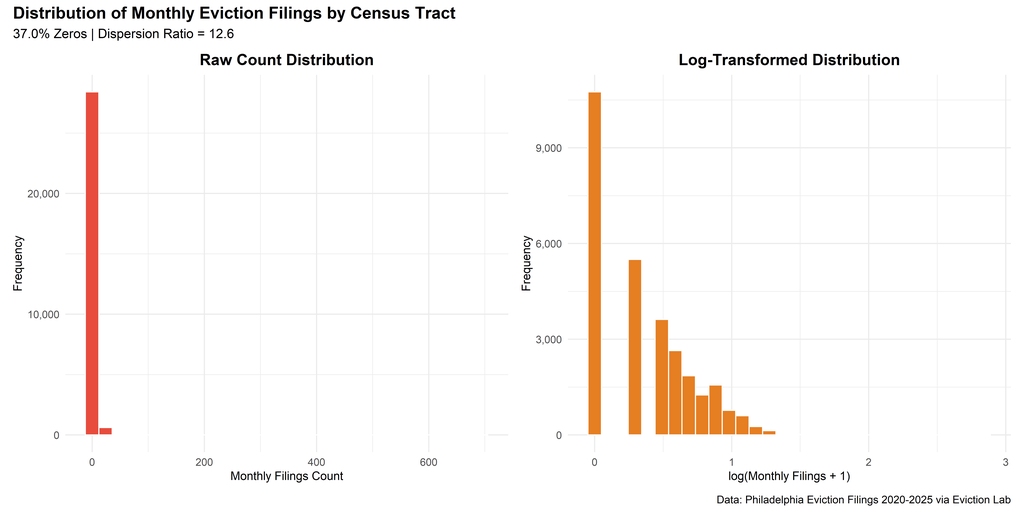

```r
# Raw distribution.
monthly_plot_raw <- df_monthly %>%
  ggplot(aes(x = filings_count)) +
  geom_histogram(bins = 30, fill = "#E74C3C", color = "white") +
  scale_x_continuous(labels = comma) +
  scale_y_continuous(labels = comma) +
  labs(
    title = "Raw Count Distribution",
    x = "Monthly Filings Count",
    y = "Frequency"
  ) +
  theme_minimal() +
  theme(
    plot.title = element_text(face = "bold", hjust = 0.5),
    axis.title = element_text(size = 10)
  )

# Log-transformed distribution.
monthly_plot_log <- df_monthly %>%
  mutate(log_filings = log10(filings_count + 1)) %>%
  ggplot(aes(x = log_filings)) +
  geom_histogram(bins = 30, fill = "#E67E22", color = "white") +
  scale_x_continuous(labels = comma) +
  scale_y_continuous(labels = comma) +
  labs(
    title = "Log-Transformed Distribution",
    x = "log(Monthly Filings + 1)",
    y = "Frequency"
  ) +
  theme_minimal() +
  theme(
    plot.title = element_text(face = "bold", hjust = 0.5),
    axis.title = element_text(size = 10)
  )

# Display combined plot.
monthly_plot_raw + monthly_plot_log +
  plot_annotation(
    title = "Distribution of Monthly Eviction Filings by Census Tract",
    subtitle = sprintf("%.1f%% Zeros | Dispersion Ratio = %.1f",
                       zero_stats_monthly$zero_pct,
                       zero_stats_monthly$dispersion_ratio),
    caption = "Data: Philadelphia Eviction Filings 2020-2025 via Eviction Lab",
    theme = theme(
      plot.title = element_text(face = "bold", size = 14),
      plot.subtitle = element_text(size = 11),
      plot.caption = element_text(size = 9)
    )
  )
```

The dispersion ratio exceeds 1, indicating overdispersion that violates the Poisson assumption of equal mean and variance. This justifies the use of Negative Binomial regression over Poisson regression. There are also 37% zero filings, so perhaps in the future a Zero Inflated Negative Binomial regression could potentially perform better even though Negative Binomial itself can handle zeros.

### Weekly Filing Distribution

```r
# Calculate zero-inflation stats for weekly data.
zero_stats_weekly <- df_weekly %>%
  summarize(
    total_obs = n(),
    zero_count = sum(filings_count == 0),
    zero_pct = zero_count / total_obs * 100,
    mean_all = mean(filings_count),
    variance = var(filings_count),
    dispersion_ratio = variance / mean_all
  )

cat("WEEKLY ZERO-INFLATION STATS\n")
```

```
WEEKLY ZERO-INFLATION STATS
```

```r
cat(sprintf("Total Observations: %s\n", comma(zero_stats_weekly$total_obs)))
```

```
Total Observations: 125,563
```

```r
cat(sprintf("Zero Filings: %s (%.1f%%)\n",
            comma(zero_stats_weekly$zero_count),
            zero_stats_weekly$zero_pct))
```

```
Zero Filings: 88,027 (70.1%)
```

```r
cat(sprintf("Mean: %.2f\n", zero_stats_weekly$mean_all))
```

```
Mean: 0.53
```

```r
cat(sprintf("Dispersion Ratio: %.2f\n", zero_stats_weekly$dispersion_ratio))
```

```
Dispersion Ratio: 5.62
```

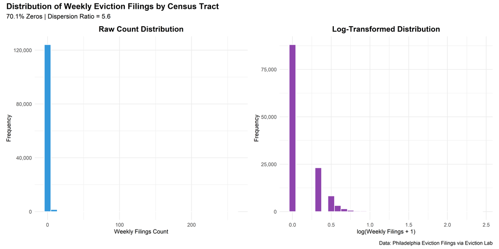

```r
# Raw distribution.
plot_weekly_raw <- df_weekly %>%
  ggplot(aes(x = filings_count)) +
  geom_histogram(bins = 30, fill = "#3498DB", color = "white") +
  scale_x_continuous(labels = comma) +
  scale_y_continuous(labels = comma) +
  labs(
    title = "Raw Count Distribution",
    x = "Weekly Filings Count",
    y = "Frequency"
  ) +
  theme_minimal() +
  theme(
    plot.title = element_text(face = "bold", hjust = 0.5),
    axis.title = element_text(size = 10)
  )

# Log-transformed distribution.
plot_weekly_log <- df_weekly %>%
  mutate(log_filings = log10(filings_count + 1)) %>%
  ggplot(aes(x = log_filings)) +
  geom_histogram(bins = 30, fill = "#8E44AD", color = "white") +
  scale_x_continuous(labels = comma) +
  scale_y_continuous(labels = comma) +
  labs(
    title = "Log-Transformed Distribution",
    x = "log(Weekly Filings + 1)",
    y = "Frequency"
  ) +
  theme_minimal() +
  theme(
    plot.title = element_text(face = "bold", hjust = 0.5),
    axis.title = element_text(size = 10)
  )

# Display combined plot.
plot_weekly_raw + plot_weekly_log +
  plot_annotation(
    title = "Distribution of Weekly Eviction Filings by Census Tract",
    subtitle = sprintf("%.1f%% Zeros | Dispersion Ratio = %.1f",
                       zero_stats_weekly$zero_pct,
                       zero_stats_weekly$dispersion_ratio),
    caption = "Data: Philadelphia Eviction Filings via Eviction Lab",
    theme = theme(plot.title = element_text(face = "bold", size = 14),
                  plot.subtitle = element_text(size = 11))
  )
```

Weekly distribution is severely zero-inflated at 70.1%, so it would not be a methodologically sound choice to use Negative Binomial with the current toolkit. While it would be more useful and actionable to provide more granular weekly predictions, this is more doable with the Zero-Inflated Negative Binomial regression in a future study.

### Tax Delinquency Distribution

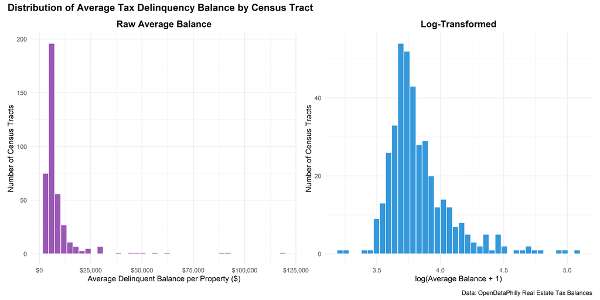

```r
# Raw distribution.
plot_tax_raw <- df_tax %>%
  ggplot(aes(x = avg_delinquent_balance_per_prop)) +
  geom_histogram(bins = 40, fill = "#9B59B6", color = "white") +
  scale_x_continuous(labels = dollar_format()) +
  scale_y_continuous(labels = comma) +
  labs(
    title = "Raw Average Balance",
    x = "Average Delinquent Balance per Property ($)",
    y = "Number of Census Tracts"
  ) +
  theme_minimal() +
  theme(plot.title = element_text(face = "bold", hjust = 0.5))

# Log-transformed distribution.
plot_tax_log <- df_tax %>%
  mutate(log_balance = log10(avg_delinquent_balance_per_prop + 1)) %>%
  ggplot(aes(x = log_balance)) +
  geom_histogram(bins = 40, fill = "#3498DB", color = "white") +
  scale_x_continuous(labels = comma) +
  scale_y_continuous(labels = comma) +
  labs(
    title = "Log-Transformed",
    x = "log(Average Balance + 1)",
    y = "Number of Census Tracts"
  ) +
  theme_minimal() +
  theme(plot.title = element_text(face = "bold", hjust = 0.5))

# Display combined plot.
plot_tax_raw + plot_tax_log +
  plot_annotation(
    title = "Distribution of Average Tax Delinquency Balance by Census Tract",
    caption = "Data: OpenDataPhilly Real Estate Tax Balances",
    theme = theme(plot.title = element_text(face = "bold", size = 14),
                  plot.subtitle = element_text(size = 11))
  )
```

### Quantile Analysis

```r
# Calculate quantiles for positive filings to understand tail behavior.
quantile_stats_monthly <- df_monthly %>%
  filter(filings_count > 0) %>%
  summarize(
    min = min(filings_count),
    q01 = quantile(filings_count, 0.01),
    q05 = quantile(filings_count, 0.05),
    q25 = quantile(filings_count, 0.25),
    median = median(filings_count),
    q75 = quantile(filings_count, 0.75),
    q95 = quantile(filings_count, 0.95),
    q99 = quantile(filings_count, 0.99),
    max = max(filings_count)
  )

# Display quantile distribution.
quantile_stats_monthly %>%
  pivot_longer(everything(), names_to = "quantile", values_to = "filings") %>%
  kable(digits = 1, caption = "Monthly Filing Count Quantiles (Positive Counts Only)",
        col.names = c("Quantile", "Filings")) %>%
  kable_styling(bootstrap_options = c("striped", "hover"))
```

Monthly Filing Count Quantiles (Positive Counts Only)

| Quantile | Filings |
| --- | --- |
| min | 1 |
| q01 | 1 |
| q05 | 1 |
| q25 | 1 |
| median | 3 |
| q75 | 5 |
| q95 | 10 |
| q99 | 16 |
| max | 694 |

Another indication that the quantiles are very inflated at 0 as median is 3, then 5 for 75th percentile, a jump to 10 at 95th percentile, another jump to 16 at the 99th percentile, and a whopping 694 jump to the max.

## 5. TEMPORAL ANALYSIS: SYSTEM-WIDE TRENDS

### Monthly Aggregate Trend with Policy Markers

```r
# Calculate total monthly filings across all tracts.
monthly_aggregate <- df_monthly %>%
  group_by(date, period) %>%
  summarize(
    total_filings = sum(filings_count, na.rm = TRUE),
    mean_filings = mean(filings_count, na.rm = TRUE),
    median_filings = median(filings_count, na.rm = TRUE),
    n_tracts = n_distinct(GEOID),
    .groups = "drop"
  )

# Create line plot with policy intervention markers.
monthly_trend_plot <- ggplot(monthly_aggregate, aes(x = date, y = total_filings)) +
  geom_line(color = "#C0392B", linewidth = 1.5) +
  geom_point(aes(color = period), size = 4) +
  # Mark start of eviction moratorium.
  geom_vline(xintercept = as.Date("2020-03-01"),
             linetype = "dashed", color = "#27AE60", linewidth = 1) +
  annotate("text", x = as.Date("2020-03-01"), y = max(monthly_aggregate$total_filings) * 0.95,
           label = "Moratorium\nStarts", hjust = -0.1, color = "#27AE60", size = 4, fontface = "bold") +
  # Mark end of eviction moratorium.
  geom_vline(xintercept = as.Date("2021-09-30"),
             linetype = "dashed", color = "#E67E22", linewidth = 1) +
  annotate("text", x = as.Date("2021-09-30"), y = max(monthly_aggregate$total_filings) * 0.85,
           label = "Moratorium\nEnds", hjust = 1.1, color = "#E67E22", size = 4, fontface = "bold") +
  scale_y_continuous(labels = comma) +
  scale_color_manual(values = period_colors) +
  labs(
    title = "Total Monthly Eviction Filings: System-Wide Trend (2020-2025)",
    subtitle = "Suppression during moratorium followed by sustained elevation after end.",
    x = "Date (Month)",
    y = "Total Monthly Filings Across All Census Tracts",
    color = "Policy Period",
    caption = "Data: Philadelphia Eviction Filings via Eviction Lab"
  ) +
  theme_minimal(base_size = 12) +
  theme(
    plot.title = element_text(face = "bold", size = 14),
    legend.position = "bottom"
  )

# Display system-wide trend plot.
monthly_trend_plot
```

[figure not shown]

```r
# Calculate summary statistics by policy period.
monthly_aggregate %>%
  group_by(period) %>%
  summarize(
    n_months = n(),
    mean_monthly = mean(total_filings),
    median_monthly = median(total_filings),
    min_monthly = min(total_filings),
    max_monthly = max(total_filings),
    sd_monthly = sd(total_filings),
    .groups = "drop"
  ) %>%
  kable(digits = 0, caption = "Monthly Filing Statistics by Policy Period",
        col.names = c("Period", "Months", "Monthly Mean", "Monthly Median", "Monthly Minimum", "Monthly Maximum", "Monthly Standard Deviation")) %>%
  kable_styling(bootstrap_options = c("striped", "hover"))
```

Monthly Filing Statistics by Policy Period

| Period | Months | Monthly Mean | Monthly Median | Monthly Minimum | Monthly Maximum | Monthly Standard Deviation |
| --- | --- | --- | --- | --- | --- | --- |
| Pre-Moratorium | 2 | 1868 | 1868 | 1720 | 2015 | 209 |
| Moratorium | 19 | 412 | 494 | 0 | 813 | 272 |
| Post-Moratorium | 50 | 1096 | 1097 | 246 | 1768 | 234 |

### Seasonality Analysis

```r
# Calculate seasonal pattern excluding moratorium period for cleaner view.
seasonality_data <- df_monthly %>%
  filter(period == "Post-Moratorium") %>%
  group_by(season) %>%
  summarize(
    mean_filings = mean(filings_count, na.rm = TRUE),
    median_filings = median(filings_count, na.rm = TRUE),
    sd_filings = sd(filings_count, na.rm = TRUE),
    .groups = "drop"
  ) %>%
  arrange(season)

# Create seasonal pattern bar plot.
seasonality_boxplot <- seasonality_data %>%
  ggplot(aes(x = season, y = mean_filings)) +
  geom_col(fill = "#3498DB", alpha = 1) +
  geom_errorbar(aes(ymin = mean_filings - sd_filings, ymax = mean_filings + sd_filings),
                width = 0.3, color = "black") +
  labs(
    title = "Seasonal Pattern in Eviction Filings",
    x = "Season",
    y = "Mean Filings per Tract-Month"
  ) +
  theme_minimal(base_size = 12) +
  theme(
    plot.title = element_text(face = "bold", size = 14, hjust = 0.5),
    axis.text.x = element_text(angle = 45, hjust = 1)
  )

# Calculate monthly pattern excluding moratorium period for cleaner view.
monthly_data <- df_monthly %>%
  filter(period == "Post-Moratorium") %>%
  group_by(month_name, month_num) %>%
  summarize(
    mean_filings = mean(filings_count, na.rm = TRUE),
    median_filings = median(filings_count, na.rm = TRUE),
    sd_filings = sd(filings_count, na.rm = TRUE),
    .groups = "drop"
  ) %>%
  arrange(month_num)

# Create monthly pattern bar plot.
monthly_boxplot <- monthly_data %>%
  ggplot(aes(x = reorder(month_name, month_num), y = mean_filings)) +
  geom_col(fill = "#3498DB", alpha = 1) +
  geom_errorbar(aes(ymin = mean_filings - sd_filings, ymax = mean_filings + sd_filings),
                width = 0.3, color = "black") +
  labs(
    title = "Monthly Pattern in Eviction Filings",
    x = "Month",
    y = "Mean Filings per Tract-Month"
  ) +
  theme_minimal(base_size = 12) +
  theme(
    plot.title = element_text(face = "bold", size = 14, hjust = 0.5),
    axis.text.x = element_text(angle = 45, hjust = 1)
  )

# Display combined plot.
# Display seasonality plot.
seasonality_boxplot + monthly_boxplot +
  plot_annotation(
    title = "Seasonal and Monthly Patterns in Eviction Filings",
    subtitle = "Post-Moratorium",
    caption = "Data: Philadelphia Eviction Claims via Eviction Lab",
    theme = theme(plot.title = element_text(face = "bold", size = 14),
                  plot.subtitle = element_text(size = 12))
  )
```

[figure not shown]

```r
# Display seasonality statistics table.
seasonality_data %>%
  kable(digits = 2, caption = "Seasonal Stats (Post-Moratorium Period)",
        col.names = c("Season", "Mean Filings", "Median Filings", "Standard Deviation Filings")) %>%
  kable_styling(bootstrap_options = c("striped", "hover"))
```

Seasonal Stats (Post-Moratorium Period)

| Season | Mean Filings | Median Filings | Standard Deviation Filings |
| --- | --- | --- | --- |
| Winter | 2.75 | 2 | 3.55 |
| Spring | 2.54 | 2 | 3.05 |
| Summer | 2.87 | 2 | 10.56 |
| Fall | 2.58 | 1 | 4.41 |

```r
# Display seasonality statistics table.
monthly_data %>%
  kable(digits = 2, caption = "Monthly Stats (Post-Moratorium Period)",
        col.names = c("Month", "Month Number", "Mean Filings", "Median Filings", "Standard Deviation Filings")) %>%
  kable_styling(bootstrap_options = c("striped", "hover"))
```

Monthly Stats (Post-Moratorium Period)

| Month | Month Number | Mean Filings | Median Filings | Standard Deviation Filings |
| --- | --- | --- | --- | --- |
| January | 1 | 2.98 | 2 | 3.57 |
| February | 2 | 2.45 | 1 | 3.72 |
| March | 3 | 2.68 | 2 | 3.09 |
| April | 4 | 2.24 | 1 | 2.77 |
| May | 5 | 2.69 | 2 | 3.26 |
| June | 6 | 2.77 | 2 | 3.98 |
| July | 7 | 2.77 | 2 | 3.28 |
| August | 8 | 3.07 | 1 | 17.56 |
| September | 9 | 2.90 | 2 | 6.51 |
| October | 10 | 2.74 | 2 | 3.25 |
| November | 11 | 2.16 | 1 | 3.13 |
| December | 12 | 2.82 | 2 | 3.34 |

### Claims Severity Over Time

```r
# Create median claim amount trend showing financial severity evolution.
claims_plot <- ggplot(df_claims %>% filter(!is.na(median_claim)),
                      aes(x = date, y = median_claim)) +
  geom_line(color = "#27AE60", linewidth = 1.5) +
  geom_point(color = "#27AE60", size = 3) +
  geom_hline(aes(yintercept = median_claim_baseline),
             linetype = "dashed", color = "#E74C3C", linewidth = 1) +
  annotate("text", x = min(df_claims$date - 100), y = df_claims$median_claim_baseline[1] + 200,
           label = sprintf("Pre-Pandemic Baseline: $%s",
                          comma(df_claims$median_claim_baseline[1])),
           hjust = 0, color = "#E74C3C", fontface = "bold") +
  geom_vline(xintercept = as.Date("2020-03-01"),
             linetype = "dotted", color = "#27AE60", alpha = 1, linewidth = 1) +
  geom_vline(xintercept = as.Date("2021-09-30"),
             linetype = "dotted", color = "#E67E22", alpha = 1, linewidth = 1) +
  scale_y_continuous(labels = dollar_format()) +
  labs(
    title = "Median Eviction Claim Amount Over Time",
    x = "Date (Month)",
    y = "Median Claim Amount ($)",
    caption = "Data: Philadelphia Eviction Claims via Eviction Lab"
  ) +
  theme_minimal(base_size = 12) +
  theme(plot.title = element_text(face = "bold", size = 14))

# Display claims trend plot.
claims_plot
```

[figure not shown]

## 6. RACIAL DISPARITY ANALYSIS

### Filing Burden by Racial Majority

```r
# Calculate filing statistics by tract racial majority.
racial_stats <- df_monthly %>%
  filter(!is.na(racial_majority), racial_majority != "") %>%
  group_by(racial_majority) %>%
  summarize(
    n_obs = n(),
    n_tracts = n_distinct(GEOID),
    total_filings = sum(filings_count, na.rm = TRUE),
    mean_filings = mean(filings_count, na.rm = TRUE),
    median_filings = median(filings_count, na.rm = TRUE),
    sd_filings = sd(filings_count, na.rm = TRUE),
    zero_pct = sum(filings_count == 0) / n() * 100,
    .groups = "drop"
  ) %>%
  mutate(
    pct_total_filings = total_filings / sum(total_filings) * 100,
    pct_tracts = n_tracts / sum(n_tracts) * 100
  )

# Display racial disparity statistics.
racial_stats %>%
  kable(digits = 2, caption = "Eviction Filing Statistics by Tract Racial Majority",
        col.names = c("Racial Majority", "Observations", "Tracts", "Filings", "Mean Filings", "Median Filings", "Standard Deviation Filings", "% Zero", "% Total Filings", "% Tracts")) %>%
  kable_styling(bootstrap_options = c("striped", "hover"))
```

Eviction Filing Statistics by Tract Racial Majority

| Racial Majority | Observations | Tracts | Filings | Mean Filings | Median Filings | Standard Deviation Filings | % Zero | % Total Filings | % Tracts |
| --- | --- | --- | --- | --- | --- | --- | --- | --- | --- |
| Black | 10366 | 146 | 33875 | 3.27 | 2 | 3.63 | 22.52 | 51.85 | 35.78 |
| Hispanic | 1633 | 23 | 3805 | 2.33 | 2 | 2.40 | 23.33 | 5.82 | 5.64 |
| Other | 6532 | 92 | 13201 | 2.02 | 1 | 3.04 | 43.05 | 20.21 | 22.55 |
| White | 10437 | 147 | 14450 | 1.38 | 1 | 2.81 | 49.77 | 22.12 | 36.03 |

```r
# Create side-by-side comparison of tract share vs filing share.
racial_comparison <- racial_stats %>%
  select(racial_majority, pct_tracts, pct_total_filings) %>%
  pivot_longer(cols = c(pct_tracts, pct_total_filings),
               names_to = "metric", values_to = "percentage") %>%
  mutate(
    metric = ifelse(metric == "pct_tracts", "Share of Tracts", "Share of Filings")
  )

# Create grouped bar plot showing disparity.
racial_disparity_plot <- racial_comparison %>%
  ggplot(aes(x = racial_majority, y = percentage, fill = metric)) +
  geom_col(position = "dodge", width = 0.7) +
  geom_text(aes(label = sprintf("%.1f%%", percentage)),
            position = position_dodge(width = 0.7), vjust = -0.5, size = 3.5) +
  scale_fill_manual(values = c("Share of Tracts" = "#3498DB", "Share of Filings" = "#E74C3C")) +
  scale_y_continuous(labels = percent_format(scale = 1), expand = expansion(mult = c(0, 0.15))) +
  labs(
    title = "Racial Disparity in Eviction Filings",
    x = "Tract Racial Majority",
    y = "Percentage",
    fill = "Metric",
    caption = "Data: Philadelphia Eviction Filings via Eviction Lab"
  ) +
  theme_minimal(base_size = 12) +
  theme(
    plot.title = element_text(face = "bold", size = 14),
    legend.position = "bottom"
  )

# Display racial disparity plot.
racial_disparity_plot
```

[figure not shown]

Black-majority tracts bear disproportionate filing burden relative to tract share.

## 7. GEOGRAPHIC ANALYSIS

### High-Risk Tract Identification

```r
# Calculate total filings by tract across full study period.
tract_totals <- df_monthly %>%
  filter(GEOID != "sealed", !is.na(GEOID), GEOID != "") %>%
  group_by(GEOID, racial_majority) %>%
  summarize(
    total_filings = sum(filings_count, na.rm = TRUE),
    mean_monthly = mean(filings_count, na.rm = TRUE),
    median_monthly = median(filings_count, na.rm = TRUE),
    sd_monthly = sd(filings_count, na.rm = TRUE),
    # Standardized measure of dispersion. Helps compare volatility. The higher the more volatile.
    cv = ifelse(mean_monthly > 0, sd_monthly / mean_monthly, NA),
    months_observed = n(),
    months_with_filings = sum(filings_count > 0),
    .groups = "drop"
  )

# Identify top 20 highest-risk tracts by total filings.
top_risk_tracts <- tract_totals %>%
  arrange(desc(total_filings)) %>%
  head(20)

# Display top risk tracts.
top_risk_tracts %>%
  select(GEOID, racial_majority, total_filings, mean_monthly, cv) %>%
  kable(digits = 2, caption = "Top 20 Highest-Risk Census Tracts (Total Filings 2020-2025)",
        col.names = c("GEOID", "Racial Majority", "Filings", "Monthly Mean", "Coefficient of Variation")) %>%
  kable_styling(bootstrap_options = c("striped", "hover"))
```

Top 20 Highest-Risk Census Tracts (Total Filings 2020-2025)

| GEOID | Racial Majority | Filings | Monthly Mean | Coefficient of Variation |
| --- | --- | --- | --- | --- |
| 42101036100 | White | 831 | 11.70 | 1.17 |
| 42101021800 | White | 827 | 11.65 | 0.79 |
| 42101030100 | Other | 713 | 10.04 | 0.65 |
| 42101026800 | Black | 608 | 8.56 | 0.68 |
| 42101027200 | Black | 590 | 8.31 | 1.55 |
| 42101024000 | Black | 579 | 8.15 | 0.74 |
| 42101025200 | Black | 548 | 7.72 | 0.67 |
| 42101017800 | Other | 545 | 7.68 | 0.55 |
| 42101027600 | Black | 518 | 7.30 | 0.65 |
| 42101030000 | Black | 508 | 7.15 | 0.58 |
| 42101023800 | Black | 491 | 6.92 | 0.79 |
| 42101015200 | Black | 487 | 6.86 | 0.70 |
| 42101020101 | Black | 471 | 6.63 | 0.74 |
| 42101034600 | Other | 471 | 6.63 | 0.88 |
| 42101008302 | Black | 455 | 6.41 | 0.69 |
| 42101035302 | White | 455 | 6.41 | 0.85 |
| 42101024300 | Black | 444 | 6.25 | 0.84 |
| 42101023900 | Black | 441 | 6.21 | 0.72 |
| 42101012201 | Black | 428 | 6.03 | 0.76 |
| 42101010800 | Black | 426 | 6.00 | 0.69 |

```r
# Calculate concentration statistics showing geographic clustering of evictions.
total_system_filings <- sum(tract_totals$total_filings)
top_20_pct <- sum(top_risk_tracts$total_filings) / total_system_filings * 100

cat("GEOGRAPHIC CONCENTRATION ANALYSIS\n")
```

```
GEOGRAPHIC CONCENTRATION ANALYSIS
```

```r
cat(sprintf("Total System Filings: %s\n", comma(total_system_filings)))
```

```
Total System Filings: 65,331
```

```r
cat(sprintf("Top 20 Tracts Account For: %.1f%% of all filings\n", top_20_pct))
```

```
Top 20 Tracts Account For: 16.6% of all filings
```

### Spatial Mapping of Eviction Burden

```r
# Join tract totals to spatial geometry.
philly_eviction_sf <- philly_tracts_sf %>%
  left_join(tract_totals, by = "GEOID")

# Create choropleth map of total filings.
eviction_map <- ggplot(philly_eviction_sf) +
  geom_sf(aes(fill = total_filings), color = NA) +
  scale_fill_viridis_c(
    option = "inferno",
    trans = "log1p",
    labels = comma,
    na.value = "gray50",
    breaks = c(0, 25, 100, 250, 831)
  ) +
  labs(
    title = "Total Eviction Filings by Census Tract (2020-2025)",
    fill = "Total\nFilings",
    caption = "Data: Philadelphia Eviction Filings via Eviction Lab"
  ) +
  theme_void() +
  theme(
    plot.title = element_text(face = "bold", size = 14, hjust = 0.5),
    plot.subtitle = element_text(size = 11, hjust = 0.5),
    legend.position = "right"
  )

# Display eviction map.
eviction_map
```

[figure not shown]

### Spatial Mapping of Tax Delinquency

```r
# Join tax data to spatial geometry.
philly_tax_sf <- philly_tracts_sf %>%
  left_join(df_tax, by = "GEOID")

# Create choropleth map of average tax balance.
tax_map <- ggplot(philly_tax_sf) +
  geom_sf(aes(fill = avg_balance), color = NA) +
  scale_fill_viridis_c(
    option = "plasma",
    trans = "log1p",
    labels = dollar_format(),
    na.value = "gray50",
    breaks = c(1000, 5000, 10000, 50000)
  ) +
  labs(
    title = "Average Property Tax Delinquency by Census Tract",
    fill = "Average\nTax\nBalance",
    caption = "Data: OpenDataPhilly Real Estate Tax Balances"
  ) +
  theme_void() +
  theme(
    plot.title = element_text(face = "bold", size = 14, hjust = 0.5),
    plot.subtitle = element_text(size = 11, hjust = 0.5),
    legend.position = "right"
  )

# Display tax map.
tax_map
```

[figure not shown]

## 8. PRE-PANDEMIC BASELINE COMPARISON

### Monthly Filings vs Baseline Ratio

```r
# Calculate system-wide ratio to pre-pandemic baseline over time.
monthly_baseline_ratio <- df_monthly %>%
  group_by(date) %>%
  summarize(
    total_filings = sum(filings_count, na.rm = TRUE),
    total_baseline = sum(filings_avg_prepandemic_baseline, na.rm = TRUE),
    .groups = "drop"
  ) %>%
  filter(total_baseline > 0) %>%
  mutate(ratio_to_baseline = total_filings / total_baseline)

# Create line plot showing normalized recovery trajectory.
# Ratio greater than 1 indicates system stress relative to historical norm.
baseline_ratio_plot <- ggplot(monthly_baseline_ratio, aes(x = date, y = ratio_to_baseline)) +
  geom_line(color = "#16A085", linewidth = 0.8, alpha = 0.6) +
  geom_smooth(method = "loess", se = TRUE, color = "#E74C3C", linewidth = 1) +
  geom_hline(yintercept = 1, linetype = "dashed", color = "black", linewidth = 1) +
  annotate("text", x = min(monthly_baseline_ratio$date + 100), y = 1.08,
           label = "Pre-Pandemic Average", hjust = 0, fontface = "bold") +
  geom_vline(xintercept = as.Date("2020-03-01"),
             linetype = "dotted", color = "#27AE60", alpha = 1, linewidth = 1) +
  geom_vline(xintercept = as.Date("2021-09-30"),
             linetype = "dotted", color = "#E67E22", alpha = 1, linewidth = 1) +
  labs(
    title = "Monthly Filings Normalized to Pre-Pandemic Baseline",
    x = "Date (Month)",
    y = "Monthly Filings / Pre-Pandemic Average Ratio",
    caption = "Data: Philadelphia Monthly Eviction Filings via Eviction Lab"
  ) +
  theme_minimal(base_size = 12) +
  theme(plot.title = element_text(face = "bold", size = 14))

# Display baseline ratio plot.
baseline_ratio_plot
```

[figure not shown]

```r
# Calculate summary statistics by policy period.
monthly_baseline_ratio %>%
  mutate(period = case_when(
    date < as.Date("2020-03-01") ~ "pre_moratorium",
    date >= as.Date("2020-03-01") & date <= as.Date("2021-09-30") ~ "moratorium",
    date > as.Date("2021-09-30") ~ "post_moratorium"
  )) %>%
  group_by(period) %>%
  summarize(
    n_weeks = n(),
    mean_ratio = mean(ratio_to_baseline, na.rm = TRUE),
    median_ratio = median(ratio_to_baseline, na.rm = TRUE),
    .groups = "drop"
  ) %>%
  kable(digits = 2, caption = "Baseline Ratio Statistics by Policy Period",
        col.names = c("Period", "Weeks", "Mean Ratio", "Median Ratio")) %>%
  kable_styling(bootstrap_options = c("striped", "hover"))
```

Baseline Ratio Statistics by Policy Period

| Period | Weeks | Mean Ratio | Median Ratio |
| --- | --- | --- | --- |
| moratorium | 19 | 0.23 | 0.25 |
| post_moratorium | 50 | 0.63 | 0.63 |
| pre_moratorium | 2 | 1.07 | 1.07 |

# II. MODELING

## 1. FEATURE ENGINEERING FOR MODELING

### Creating Temporal Lag Variables

Temporal lags capture the momentum or inertia in eviction filing patterns. A tract with high filings last month is likely to have elevated filings this month.

```r
# Create lagged features.
# When predicting month t, we can only use data from months t-1, t-2, t-3, etc.
df_model_prep <- df_monthly %>%
  filter(GEOID != "sealed", !is.na(GEOID), GEOID != "") %>%
  arrange(GEOID, date) %>%
  group_by(GEOID) %>%
  mutate(
    # One month lag captures immediate momentum.
    filings_lag1 = lag(filings_count, n = 1, order_by = date),
    # Two month lag captures medium-term trend.
    filings_lag2 = lag(filings_count, n = 2, order_by = date),
    # Three month lag captures quarterly pattern.
    filings_lag3 = lag(filings_count, n = 3, order_by = date),
    # Rolling 3-month average of lagged values (t-1, t-2, t-3).
    # Original rollmean with align = "right" included current month, please don't change this.
    filings_ma3 = (filings_lag1 + filings_lag2 + filings_lag3) / 3
  ) %>%
  ungroup()

# Check missingness of lag variables.
lag_coverage <- df_model_prep %>%
  summarize(
    total_obs = n(),
    missing_lag1 = sum(is.na(filings_lag1)),
    missing_lag2 = sum(is.na(filings_lag2)),
    missing_lag3 = sum(is.na(filings_lag3)),
    missing_ma3 = sum(is.na(filings_ma3)),
    pct_missing_lag1 = missing_lag1 / total_obs * 100,
    pct_missing_lag2 = missing_lag2 / total_obs * 100,
    pct_missing_lag3 = missing_lag3 / total_obs * 100,
    pct_missing_ma3 = missing_ma3 / total_obs * 100
  )

# Display lag coverage stats.
lag_coverage %>%
  kable(digits = 1, caption = "Lagged Variable Coverage Stats",
        col.names = c("Observations", "Missing Lag 1", "Missing Lag 2", "Missing Lag 3", "Missing Lag 3-Month Rolling Average", "% Missing Lag 1", "% Missing Lag 2", "% Missing Lag 3", "% Missing Lag 3-Month Rolling Average")) %>%
  kable_styling(bootstrap_options = c("striped", "hover"))
```

Lagged Variable Coverage Stats

| Observations | Missing Lag 1 | Missing Lag 2 | Missing Lag 3 | Missing Lag 3-Month Rolling Average | % Missing Lag 1 | % Missing Lag 2 | % Missing Lag 3 | % Missing Lag 3-Month Rolling Average |
| --- | --- | --- | --- | --- | --- | --- | --- | --- |
| 28968 | 408 | 816 | 1224 | 1224 | 1.4 | 2.8 | 4.2 | 4.2 |

```r
# There are around 37% zeros, so add zero flags for last month and consecutive.
df_model_prep <- df_model_prep %>%
  group_by(GEOID) %>%
  mutate(
    was_zero_last_month = lag(ifelse(filings_count == 0, 1, 0)),
    consecutive_zeros = sequence(rle(filings_count == 0)$lengths) * (filings_count == 0)
  ) %>%
  ungroup()

# Check missingness of zero flag variables.
zero_coverage <- df_model_prep %>%
  summarize(
    total_obs = n(),
    missing_zero_last_month = sum(is.na(was_zero_last_month)),
    missing_consecutive_zeros = sum(is.na(consecutive_zeros)),
    pct_missing_zero_last_month = missing_zero_last_month / total_obs * 100,
    pct_missing_consecutive_zeros = missing_consecutive_zeros / total_obs * 100
  )

# Display zero flag coverage stats.
zero_coverage %>%
  kable(digits = 1, caption = "Zero Flag Variable Coverage Stats",
        col.names = c("Observations", "Missing 0 Last Month", "Missing Consecutive Zeros", "% Missing 0 Last Month", "% Missing Consecutive Zeros")) %>%
  kable_styling(bootstrap_options = c("striped", "hover"))
```

Zero Flag Variable Coverage Stats

| Observations | Missing 0 Last Month | Missing Consecutive Zeros | % Missing 0 Last Month | % Missing Consecutive Zeros |
| --- | --- | --- | --- | --- |
| 28968 | 408 | 0 | 1.4 | 0 |

### Merging Claims Severity Data

```r
# Create year-month key for joining claims data to tract-level data.
df_model_prep <- df_model_prep %>%
  mutate(year_month = floor_date(date, "month"))

df_claims_join <- df_claims %>%
  mutate(year_month = floor_date(date, "month")) %>%
  select(year_month, median_claim, claim_ratio)

# Merge claims data to tract-level panel.
df_model_prep <- df_model_prep %>%
  left_join(df_claims_join, by = "year_month")

# Check merge success.
claims_merge_stats <- df_model_prep %>%
  summarize(
    total_obs = n(),
    has_claims = sum(!is.na(median_claim)),
    pct_with_claims = has_claims / total_obs * 100
  )

cat(sprintf("Observations with claims data: %s (%.1f%%)\n",
            comma(claims_merge_stats$has_claims),
            claims_merge_stats$pct_with_claims))
```

```
Observations with claims data: 27,336 (94.4%)
```

### Merging Tax Delinquency Data

Tax delinquency serves as a proxy for landlord financial stress. Properties with outstanding tax balances may have landlords more likely to pursue evictions.

```r
# Prepare tax data for joining.
df_tax_join <- df_tax %>%
  select(GEOID, num_props, balance, avg_balance, log_delinquent_balance,
                delinquent_prop_count, delinquency_age_years)

# Merge tax delinquency data to tract-level panel.
df_model_prep <- df_model_prep %>%
  left_join(df_tax_join, by = "GEOID")

# Check merge success.
tax_merge_stats <- df_model_prep %>%
  summarize(
    total_obs = n(),
    has_tax_data = sum(!is.na(avg_balance)),
    pct_with_tax = has_tax_data / total_obs * 100
  )

cat(sprintf("Observations with tax data: %s (%.1f%%)\n",
            comma(tax_merge_stats$has_tax_data),
            tax_merge_stats$pct_with_tax))
```

```
Observations with tax data: 28,116 (97.1%)
```

### Integrating ACS Socioeconomic Data

American Community Survey data provides tract-level socioeconomic indicators that capture structural vulnerability to eviction. Variables chosen are related to housing, income, and demographic composition.

```r
# Retrieve ACS 5-year estimates for Philadelphia County tracts.
# Using 2023 ACS 5-year estimates.

# Define ACS variables to retrieve.
acs_vars <- c(
  # Housing characteristics.
  "B25003_001",  # total occupied housing units
  "B25003_003",  # renter-occupied units
  "B25064_001",  # median gross rent
  "B25071_001",  # median gross rent as % of income
  "B25077_001",  # median home value


  # Income and poverty.
  "B19013_001",  # median household income
  "B17001_001",  # total population for poverty status
  "B17001_002",  # population below poverty level

  # Employment.
  "B23025_001",  # total population 16+ in labor force
  "B23025_005",  # unemployed population

  # Education.
  "B15003_001",  # total population 25+ for education
  "B15003_017",  # high school diploma
  "B15003_022",  # bachelor's degree
  "B15003_023",  # master's degree
  "B15003_025",  # doctorate degree

  # Demographics.
  "B01003_001",  # total population
  "B01002_001",  # median age

  # Household composition.
  "B11001_001",  # total households
  "B11001_006",  # female householder no spouse with children

  # Housing cost burden.
  "B25070_001",  # total renter households for rent burden
  "B25070_007",  # renters paying 30-34.9% income on rent
  "B25070_008",  # renters paying 35-39.9% income on rent
  "B25070_009",  # renters paying 40-49.9% income on rent
  "B25070_010"   # renters paying 50%+ income on rent
)

# Retrieve ACS data for Philadelphia County.
acs_data <- get_acs(
  geography = "tract",
  variables = acs_vars,
  state = "PA",
  county = "Philadelphia",
  year = 2023,
  survey = "acs5",
  output = "wide",
  geometry = FALSE
)

cat(sprintf("Tracts with ACS data: %d\n", nrow(acs_data)))
```

```
Tracts with ACS data: 408
```

```r
# Engineer meaningful features from raw ACS variables.
df_acs <- acs_data %>%
  transmute(
    GEOID = GEOID,

    # Renter percentage.
    pct_renter = ifelse(B25003_001E > 0, B25003_003E / B25003_001E * 100, NA),

    # Median gross rent.
    median_rent = B25064_001E,

    # Rent burden (rent as % of income).
    rent_burden_pct = B25071_001E,

    # Median household income (log transform for modeling).
    median_income = B19013_001E,
    log_median_income = log1p(B19013_001E),

    # Poverty rate.
    poverty_rate = ifelse(B17001_001E > 0, B17001_002E / B17001_001E * 100, NA),

    # Unemployment rate.
    unemployment_rate = ifelse(B23025_001E > 0, B23025_005E / B23025_001E * 100, NA),

    # Educational attainment (% with at least bachelor's).
    pct_college = ifelse(B15003_001E > 0,
                         (B15003_022E + B15003_023E + B15003_025E) / B15003_001E * 100, NA),

    # Total population.
    total_pop = B01003_001E,
    log_pop = log1p(B01003_001E),

    # Median age.
    median_age = B01002_001E,

    # Single mother households (% total households).
    pct_single_mother = ifelse(B11001_001E > 0, B11001_006E / B11001_001E * 100, NA),

    # Severe rent burden (% renters paying 35%+ income on rent).
    severe_rent_burden = ifelse(B25070_001E > 0,
                                (B25070_008E + B25070_009E + B25070_010E) / B25070_001E * 100, NA)
  )
```

```r
# Calculate summary stats for ACS features.
acs_summary <- df_acs %>%
  select(-GEOID) %>%
  pivot_longer(everything(), names_to = "variable", values_to = "value") %>%
  group_by(variable) %>%
  summarize(
    mean = mean(value, na.rm = TRUE),
    median = median(value, na.rm = TRUE),
    sd = sd(value, na.rm = TRUE),
    min = min(value, na.rm = TRUE),
    max = max(value, na.rm = TRUE),
    pct_missing = sum(is.na(value)) / n() * 100,
    .groups = "drop"
  )

acs_summary %>%
  kable(digits = 2, caption = "ACS Feature Summary Stats",
        col.names = c("Variable", "Mean", "Median", "Standard Deviation", "Minimum", "Maximum", "% Missing")) %>%
  kable_styling(bootstrap_options = c("striped", "hover"))
```

ACS Feature Summary Stats

| Variable | Mean | Median | Standard Deviation | Minimum | Maximum | % Missing |
| --- | --- | --- | --- | --- | --- | --- |
| log_median_income | 10.99 | 11.02 | 0.49 | 9.53 | 12.17 | 6.62 |
| log_pop | 7.86 | 8.25 | 1.72 | 0.00 | 9.25 | 0.00 |
| median_age | 36.76 | 35.40 | 7.71 | 5.70 | 74.90 | 4.17 |
| median_income | 66877.27 | 60817.00 | 33071.00 | 13721.00 | 192727.00 | 6.62 |
| median_rent | 1374.54 | 1285.50 | 391.30 | 407.00 | 3132.00 | 6.37 |
| pct_college | 33.01 | 27.31 | 21.37 | 1.50 | 92.42 | 4.17 |
| pct_renter | 48.21 | 47.15 | 20.49 | 0.00 | 100.00 | 4.90 |
| pct_single_mother | 19.53 | 18.12 | 13.53 | 0.00 | 62.82 | 4.90 |
| poverty_rate | 21.60 | 18.54 | 14.04 | 0.00 | 73.91 | 4.66 |
| rent_burden_pct | 33.56 | 31.40 | 9.46 | 17.30 | 51.00 | 5.64 |
| severe_rent_burden | 41.35 | 41.01 | 17.05 | 4.19 | 100.00 | 5.15 |
| total_pop | 3878.51 | 3813.50 | 1834.07 | 0.00 | 10406.00 | 0.00 |
| unemployment_rate | 5.18 | 4.62 | 3.43 | 0.00 | 19.64 | 4.17 |

```r
# Merge ACS data into model prep dataset.
df_model_prep <- df_model_prep %>%
  left_join(df_acs, by = "GEOID")

# Check merge.
acs_merge_stats <- df_model_prep %>%
  summarize(
    total_obs = n(),
    has_acs = sum(!is.na(pct_renter)),
    pct_with_acs = has_acs / total_obs * 100
  )

cat(sprintf("Observations with ACS data: %s (%.1f%%)\n",
            comma(acs_merge_stats$has_acs),
            acs_merge_stats$pct_with_acs))
```

```
Observations with ACS data: 27,548 (95.1%)
```

```r
# Filter spatial data to only tracts present in eviction data.
tracts_in_data <- unique(df_model_prep$GEOID)

philly_model_sf <- philly_tracts_sf %>%
  filter(GEOID %in% tracts_in_data)

# Create spatial neighbors using Queen contiguity.
neighbors_queen <- poly2nb(philly_model_sf, queen = TRUE)

# Convert to spatial weights matrix.
weights_matrix <- nb2listw(neighbors_queen, style = "W", zero.policy = TRUE)

cat(sprintf("Number of tracts in spatial analysis: %d\n", length(neighbors_queen)))
```

```
Number of tracts in spatial analysis: 408
```

```r
cat(sprintf("Average number of neighbors per tract: %.1f\n",
            mean(card(neighbors_queen))))
```

```
Average number of neighbors per tract: 6.0
```

```r
# Calculate lagged spatial lag of filings for each month.
# Use neighbors' filings from month t-1 (previous month).
# Using same-month neighbor data would be data leakage since we wouldn't have that info at prediction time.

# Create function to calculate spatial lag for a given month using previous month's data.
# Shift each tract's filings by 1 month.
df_model_prep <- df_model_prep %>%
  arrange(GEOID, date) %>%
  group_by(GEOID) %>%
  mutate(filings_count_lag1 = lag(filings_count, n = 1)) %>%
  ungroup()

# For each month, calculate spatial lag using the lagged filings.
df_model_prep <- df_model_prep %>%
  group_by(date) %>%
  mutate(
    # Match order to spatial data for this month.
    spatial_lag_filings = {
      sf_matched <- philly_model_sf %>%
        left_join(
          cur_data() %>% select(GEOID, filings_count_lag1),
          by = "GEOID"
        ) %>%
        mutate(filings_count_lag1 = ifelse(is.na(filings_count_lag1), 0, filings_count_lag1))

      # Calculate weighted average of neighbors' lagged filings.
      lag.listw(weights_matrix, sf_matched$filings_count_lag1, zero.policy = TRUE)
    }
  ) %>%
  ungroup()

cat(sprintf("Observations with spatial lag: %s\n",
            comma(sum(!is.na(df_model_prep$spatial_lag_filings)))))
```

```
Observations with spatial lag: 28,968
```

```r
# Load boundaries.
neighborhoods <- st_read("data/philadelphia-neighborhoods/philadelphia-neighborhoods.shp")
# Make valid for duplicate vertex error.
neighborhoods <- st_make_valid(neighborhoods)

# Change CRS.
neighborhoods <- st_transform(neighborhoods, st_crs(philly_model_sf))

# Select only GEOID and geometry from tracts.
tracts_sf_subset <- philly_model_sf %>% select(GEOID, geometry)

# Select only neighborhood name and geometry from neighborhoods.
neighborhoods_sf_subset <- neighborhoods %>% select(MAPNAME, geometry) %>% rename(neighborhood = MAPNAME)

# Spatial join. Keep tracts even if they don't perfectly intersect a neighborhood.
tracts_with_neighborhood <- st_join(
    tracts_sf_subset,
    neighborhoods_sf_subset,
    join = st_intersects,
    left = TRUE
) %>%
    # Drop geometry.
    st_drop_geometry()

# Select only GEOID and neighborhood.
df_neighborhood_join <- tracts_with_neighborhood %>%
    select(GEOID, neighborhood)

# Choose first match if multiple.
df_neighborhood_join <- df_neighborhood_join %>%
    group_by(GEOID) %>%
    slice(1) %>%
    ungroup()

# Merge.
df_model_prep <- df_model_prep %>%
    left_join(df_neighborhood_join, by = "GEOID")

# Check merge.
cat(sprintf("Total observations: %s\n", comma(nrow(df_model_prep))))
```

```
Total observations: 28,968
```

```r
cat(sprintf("Observations with neighborhood data: %s\n",
            comma(sum(!is.na(df_model_prep$neighborhood)))))
```

```
Observations with neighborhood data: 28,968
```

```r
# Convert new column to factor for FE.
df_model_prep$neighborhood <- as.factor(df_model_prep$neighborhood)

# Change reference.
df_model_prep$neighborhood <- relevel(df_model_prep$neighborhood, ref = "East Falls")
```

```r
# Define threshold for capping target variable in training set.
cap_threshold = 20

# Create spike binary flag for all data to identify structural risk.
df_model_prep <- df_model_prep %>%
  mutate(is_extreme_spike = ifelse(filings_count > cap_threshold, 1, 0))
```

```r
# Custom colors.
custom_colors <- colorRampPalette(c("#f03e37", "white", "#189ace"))

color_vector <- custom_colors(200)

# Select and apply numeric columns only.
df_model_prep_correlation <- df_model_prep[, sapply(df_model_prep, is.numeric)]

# Correlation matrix.
correlation_matrix <- cor(df_model_prep_correlation, use = "pairwise.complete.obs")

# Display matrix.
corrplot(correlation_matrix,
         method = "square",
         order = "FPC",
         type = "lower",
         diag = TRUE,
         tl.col = "black",
         cl.pos = "n",
         addCoef.col = "black",
         col = color_vector
         )
```

[figure not shown]

Modeling Notes:

- Likely use `poverty_rate` over `log_median_income`, they measure the same concept, but poverty rate has a stronger theoretical link to evictions.
- Use `delinquent_prop_count` over `log_delinquent_balance` it has a stronger correlation to the target.
- Likely use filings_ma3 (3-month rolling average) over `filings_lag1` and `filings_lag2`, it captures both of them so it makes it redundant.

## 2. TRAIN/TEST SPLIT STRATEGY

### Time-Based Validation Split

For a truly predictive model, we must use time-based splitting to avoid data leakage. The model learns from historical data and predicts future periods.

```r
# Define temporal cutoff for train/test split.
train_end_date <- as.Date("2023-12-31")
test_start_date <- as.Date("2024-01-01")

# Filter for all variables needed by most complex model.
df_filtered <- df_model_prep %>%
  filter(
    !is.na(filings_ma3),
    !is.na(spatial_lag_filings),
    !is.na(delinquent_prop_count),
    !is.na(pct_renter),
    !is.na(poverty_rate),
    !is.na(severe_rent_burden),
    !is.na(pct_single_mother),
    !is.na(racial_majority),
    !is.na(moratorium_active),
    !is.na(neighborhood)
  )

# Apply the cap only to training target variable to make it stable.
# Create training set where filings are capped at 99.75 percentile = 20 filings.
df_train <- df_filtered %>%
  filter(date <= train_end_date) %>%
  mutate(filings_count_capped = pmin(filings_count, cap_threshold))

# Create testing set where target is including spikes for real-world.
df_test <- df_filtered %>%
  filter(date >= test_start_date)

# Display split statistics.
cat("TRAIN/TEST SPLIT SUMMARY\n")
```

```
TRAIN/TEST SPLIT SUMMARY
```

```r
cat(sprintf("Training Period: %s to %s\n", min(df_train$date), max(df_train$date)))
```

```
Training Period: 2020-04-01 to 2023-12-01
```

```r
cat(sprintf("Training Observations: %s\n", comma(nrow(df_train))))
```

```
Training Observations: 17,280
```

```r
cat(sprintf("Training Months: %d\n", n_distinct(df_train$date)))
```

```
Training Months: 45
```

```r
cat(sprintf("Test Period: %s to %s\n", min(df_test$date), max(df_test$date)))
```

```
Test Period: 2024-01-01 to 2025-11-01
```

```r
cat(sprintf("Test Observations: %s\n", comma(nrow(df_test))))
```

```
Test Observations: 8,832
```

```r
cat(sprintf("Test Months: %d\n", n_distinct(df_test$date)))
```

```
Test Months: 23
```

```r
# Adjust so that the extreme outliers are not included. Cap lagged momentum signal to reduce distortion from rare mass-eviction spikes, which is 99.8 percentile.
df_train <- df_train %>% mutate(filings_ma3 = pmin(filings_ma3, 20))
df_test <- df_test %>% mutate(filings_ma3 = pmin(filings_ma3, 20))
```

```r
# Compare filing distributions between train and test sets.
train_test_comparison <- bind_rows(
  df_train %>% mutate(set = "training"),
  df_test %>% mutate(set = "test")
) %>%
  group_by(set) %>%
  summarize(
    n_obs = n(),
    mean_filings = mean(filings_count, na.rm = TRUE),
    median_filings = median(filings_count, na.rm = TRUE),
    sd_filings = sd(filings_count, na.rm = TRUE),
    zero_pct = sum(filings_count == 0) / n() * 100,
    .groups = "drop"
  )

train_test_comparison %>%
  kable(digits = 2, caption = "Filing Distribution Comparison: Training vs Test Sets",
        col.names = c("Set", "Observations", "Mean Filings", "Median Filings", "Standard Deviation Filings", "% Zero")) %>%
  kable_styling(bootstrap_options = c("striped", "hover"))
```

Filing Distribution Comparison: Training vs Test Sets

| Set | Observations | Mean Filings | Median Filings | Standard Deviation Filings | % Zero |
| --- | --- | --- | --- | --- | --- |
| test | 8832 | 2.64 | 2 | 3.20 | 27.39 |
| training | 17280 | 2.12 | 1 | 3.17 | 37.60 |

## 3. NEGATIVE BINOMIAL REGRESSION MODEL

### Model Specification Rationale

Because of overdispersion, Negative Binomial regression is preferred over Poisson.

### Model 1: Baseline with Temporal, Policy, and Monthly Features

```r
# Fit baseline Negative Binomial model with core time, policy, and monthly predictors.
model_nb_1 <- glm.nb(filings_count_capped ~ filings_ma3 + moratorium_active + factor(month_num) + is_extreme_spike,
                     data = df_train)

# Display 1st model summary.
cat("BASELINE NEGATIVE BINOMIAL MODEL SUMMARY\n")
```

```
BASELINE NEGATIVE BINOMIAL MODEL SUMMARY
```

```r
summary(model_nb_1)
```

```
Call:
glm.nb(formula = filings_count_capped ~ filings_ma3 + moratorium_active +
    factor(month_num) + is_extreme_spike, data = df_train, init.theta = 1.652485134,
    link = log)

Coefficients:
                     Estimate Std. Error z value             Pr(>|z|)
(Intercept)          0.406671   0.032979  12.331 < 0.0000000000000002 ***
filings_ma3          0.211950   0.002944  72.000 < 0.0000000000000002 ***
moratorium_active   -0.587494   0.019745 -29.754 < 0.0000000000000002 ***
factor(month_num)2  -0.264619   0.045157  -5.860   0.0000000046293608 ***
factor(month_num)3   0.018918   0.043832   0.432             0.666037
factor(month_num)4  -0.722253   0.045008 -16.047 < 0.0000000000000002 ***
factor(month_num)5  -0.432966   0.043909  -9.861 < 0.0000000000000002 ***
factor(month_num)6  -0.338440   0.043762  -7.734   0.0000000000000104 ***
factor(month_num)7  -0.143537   0.043031  -3.336             0.000851 ***
factor(month_num)8   0.010293   0.042140   0.244             0.807022
factor(month_num)9   0.118125   0.041477   2.848             0.004400 **
factor(month_num)10  0.029408   0.040993   0.717             0.473130
factor(month_num)11 -0.125061   0.041365  -3.023             0.002500 **
factor(month_num)12 -0.092971   0.041199  -2.257             0.024029 *
is_extreme_spike     1.666549   0.129682  12.851 < 0.0000000000000002 ***
---
Signif. codes:  0 '***' 0.001 '**' 0.01 '*' 0.05 '.' 0.1 ' ' 1

(Dispersion parameter for Negative Binomial(1.6525) family taken to be 1)

    Null deviance: 27521  on 17279  degrees of freedom
Residual deviance: 18556  on 17265  degrees of freedom
AIC: 60201

Number of Fisher Scoring iterations: 1

              Theta:  1.6525
          Std. Err.:  0.0388

 2 x log-likelihood:  -60169.1300
```

### Model 2: Add Tax Delinquency and Spatial Lag

```r
model_nb_2 <- glm.nb(filings_count_capped ~
                       filings_ma3 + moratorium_active + factor(month_num) + is_extreme_spike +
                       # Added spatial lag and delinquent properties because they're more actionable.
                       spatial_lag_filings + delinquent_prop_count,
                     data = df_train)

# Display 2nd model summary.
cat("2ND NEGATIVE BINOMIAL MODEL SUMMARY\n")
```

```
2ND NEGATIVE BINOMIAL MODEL SUMMARY
```

```r
summary(model_nb_2)
```

```
Call:
glm.nb(formula = filings_count_capped ~ filings_ma3 + moratorium_active +
    factor(month_num) + is_extreme_spike + spatial_lag_filings +
    delinquent_prop_count, data = df_train, init.theta = 1.785836474,
    link = log)

Coefficients:
                         Estimate  Std. Error z value             Pr(>|z|)
(Intercept)            0.16958717  0.03601190   4.709   0.0000024869281117 ***
filings_ma3            0.18508414  0.00302674  61.150 < 0.0000000000000002 ***
moratorium_active     -0.59704251  0.02096097 -28.484 < 0.0000000000000002 ***
factor(month_num)2    -0.26768237  0.04441417  -6.027   0.0000000016707370 ***
factor(month_num)3     0.03809786  0.04309203   0.884             0.376640
factor(month_num)4    -0.70713449  0.04430404 -15.961 < 0.0000000000000002 ***
factor(month_num)5    -0.41107419  0.04346477  -9.458 < 0.0000000000000002 ***
factor(month_num)6    -0.32981983  0.04313644  -7.646   0.0000000000000207 ***
factor(month_num)7    -0.14707775  0.04236759  -3.471             0.000518 ***
factor(month_num)8     0.00797282  0.04146404   0.192             0.847521
factor(month_num)9     0.10634056  0.04078377   2.607             0.009123 **
factor(month_num)10    0.03113026  0.04025258   0.773             0.439302
factor(month_num)11   -0.12814163  0.04065231  -3.152             0.001621 **
factor(month_num)12   -0.08544880  0.04048530  -2.111             0.034806 *
is_extreme_spike       1.82586047  0.12550920  14.548 < 0.0000000000000002 ***
spatial_lag_filings    0.02619239  0.00486258   5.387   0.0000000718332945 ***
delinquent_prop_count  0.00099969  0.00004104  24.361 < 0.0000000000000002 ***
---
Signif. codes:  0 '***' 0.001 '**' 0.01 '*' 0.05 '.' 0.1 ' ' 1

(Dispersion parameter for Negative Binomial(1.7858) family taken to be 1)

    Null deviance: 28450  on 17279  degrees of freedom
Residual deviance: 18548  on 17263  degrees of freedom
AIC: 59653

Number of Fisher Scoring iterations: 1

              Theta:  1.7858
          Std. Err.:  0.0434

 2 x log-likelihood:  -59616.6730
```

### Model 3: Add ACS

```r
model_nb_3 <- glm.nb(filings_count_capped ~
                       # 1st model.
                       filings_ma3 + moratorium_active + factor(month_num) + is_extreme_spike + neighborhood +
                       # 2nd model.
                       spatial_lag_filings + delinquent_prop_count +
                       # Add demographics.
                       pct_renter + severe_rent_burden + poverty_rate + pct_single_mother +
                       factor(racial_majority),
                     data = df_train)

# Display 3rd model summary.
cat("3RD NEGATIVE BINOMIAL MODEL SUMMARY\n")
```

```
3RD NEGATIVE BINOMIAL MODEL SUMMARY
```

```r
summary(model_nb_3)
```

```
Call:
glm.nb(formula = filings_count_capped ~ filings_ma3 + moratorium_active +
    factor(month_num) + is_extreme_spike + neighborhood + spatial_lag_filings +
    delinquent_prop_count + pct_renter + severe_rent_burden +
    poverty_rate + pct_single_mother + factor(racial_majority),
    data = df_train, init.theta = 2.456047024, link = log)

Coefficients:
                                           Estimate  Std. Error z value
(Intercept)                             -0.32885876  0.08373969  -3.927
filings_ma3                              0.10824420  0.00324140  33.394
moratorium_active                       -0.72840866  0.02044538 -35.627
factor(month_num)2                      -0.26247687  0.04149013  -6.326
factor(month_num)3                       0.04896265  0.04011348   1.221
factor(month_num)4                      -0.67002325  0.04171184 -16.063
factor(month_num)5                      -0.41028851  0.04087245 -10.038
factor(month_num)6                      -0.33329963  0.04040477  -8.249
factor(month_num)7                      -0.18329105  0.03969309  -4.618
factor(month_num)8                      -0.01468898  0.03872740  -0.379
factor(month_num)9                       0.08037622  0.03807647   2.111
factor(month_num)10                     -0.00068793  0.03751738  -0.018
factor(month_num)11                     -0.14435744  0.03793421  -3.805
factor(month_num)12                     -0.08616436  0.03772642  -2.284
is_extreme_spike                         1.75915476  0.11004495  15.986
neighborhoodAcademy Gardens              0.46868176  0.15752547   2.975
neighborhoodAllegheny West              -0.48975161  0.10430841  -4.695
neighborhoodAndorra                     -3.70144762  1.00371354  -3.688
neighborhoodBartram Village             -0.47563860  0.11981972  -3.970
neighborhoodBelmont                     -0.00989062  0.13651137  -0.072
neighborhoodBrewerytown                 -0.10763228  0.08395922  -1.282
neighborhoodBridesburg                  -0.53703472  0.12210109  -4.398
neighborhoodBurholme                     0.34905619  0.14083720   2.478
neighborhoodBustleton                    0.10438794  0.07693362   1.357
neighborhoodByberry                      0.67177557  0.12873656   5.218
neighborhoodCarroll Park                 0.14207463  0.13914364   1.021
neighborhoodCedar Park                   0.05976045  0.17349190   0.344
neighborhoodCedarbrook                  -0.00166750  0.09703355  -0.017
neighborhoodCenter City East            -0.41877600  0.11827091  -3.541
neighborhoodChestnut Hill               -0.67456234  0.10638519  -6.341
neighborhoodClearview                    0.28564927  0.08874398   3.219
```

[output cut: 236 more lines]

```
---
Signif. codes:  0 '***' 0.001 '**' 0.01 '*' 0.05 '.' 0.1 ' ' 1

(Dispersion parameter for Negative Binomial(2.456) family taken to be 1)

    Null deviance: 32272  on 17279  degrees of freedom
Residual deviance: 18400  on 17147  degrees of freedom
AIC: 57706

Number of Fisher Scoring iterations: 1

              Theta:  2.4560
          Std. Err.:  0.0686

 2 x log-likelihood:  -57437.6890
```

### Model 4: Full Model with Interactions

```r
model_nb_4 <- glm.nb(filings_count_capped ~
                       # 1st model.
                       filings_ma3 + moratorium_active + factor(month_num) + is_extreme_spike + neighborhood +
                       # 2nd model.
                       spatial_lag_filings + delinquent_prop_count +
                       # 3rd model.
                       pct_renter + severe_rent_burden + poverty_rate + pct_single_mother +
                       factor(racial_majority) +
                       # Add interactions.
                       factor(racial_majority) * moratorium_active,
                     data = df_train)

cat("FULL NEGATIVE BINOMIAL MODEL SUMMARY\n")
```

```
FULL NEGATIVE BINOMIAL MODEL SUMMARY
```

```r
summary(model_nb_4)
```

```
Call:
glm.nb(formula = filings_count_capped ~ filings_ma3 + moratorium_active +
    factor(month_num) + is_extreme_spike + neighborhood + spatial_lag_filings +
    delinquent_prop_count + pct_renter + severe_rent_burden +
    poverty_rate + pct_single_mother + factor(racial_majority) +
    factor(racial_majority) * moratorium_active, data = df_train,
    init.theta = 2.465189995, link = log)

Coefficients:
                                                    Estimate Std. Error z value
(Intercept)                                       -0.3248197  0.0838622  -3.873
filings_ma3                                        0.1080455  0.0032524  33.220
moratorium_active                                 -0.7519105  0.0281807 -26.682
factor(month_num)2                                -0.2630601  0.0414593  -6.345
factor(month_num)3                                 0.0488936  0.0400794   1.220
factor(month_num)4                                -0.6696615  0.0416854 -16.065
factor(month_num)5                                -0.4092353  0.0408380 -10.021
factor(month_num)6                                -0.3326693  0.0403722  -8.240
factor(month_num)7                                -0.1830087  0.0396631  -4.614
factor(month_num)8                                -0.0149657  0.0386996  -0.387
factor(month_num)9                                 0.0807294  0.0380454   2.122
factor(month_num)10                               -0.0006626  0.0374831  -0.018
factor(month_num)11                               -0.1440741  0.0378994  -3.801
factor(month_num)12                               -0.0850610  0.0376887  -2.257
is_extreme_spike                                   1.7676705  0.1098917  16.086
neighborhoodAcademy Gardens                        0.4680273  0.1577582   2.967
neighborhoodAllegheny West                        -0.4861105  0.1042729  -4.662
neighborhoodAndorra                               -3.7044683  1.0035887  -3.691
neighborhoodBartram Village                       -0.4749069  0.1197343  -3.966
neighborhoodBelmont                               -0.0055532  0.1364268  -0.041
neighborhoodBrewerytown                           -0.1048998  0.0839285  -1.250
neighborhoodBridesburg                            -0.5357079  0.1220534  -4.389
neighborhoodBurholme                               0.3446663  0.1405201   2.453
neighborhoodBustleton                              0.1048551  0.0769905   1.362
neighborhoodByberry                                0.6730944  0.1288547   5.224
neighborhoodCarroll Park                           0.1460024  0.1390734   1.050
neighborhoodCedar Park                             0.0569091  0.1738193   0.327
neighborhoodCedarbrook                             0.0005676  0.0969952   0.006
neighborhoodCenter City East                      -0.4180745  0.1183566  -3.532
neighborhoodChestnut Hill                         -0.6696446  0.1062139  -6.305
```

[output cut: 243 more lines]

```
---
Signif. codes:  0 '***' 0.001 '**' 0.01 '*' 0.05 '.' 0.1 ' ' 1

(Dispersion parameter for Negative Binomial(2.4652) family taken to be 1)

    Null deviance: 32316  on 17279  degrees of freedom
Residual deviance: 18401  on 17144  degrees of freedom
AIC: 57691

Number of Fisher Scoring iterations: 1

              Theta:  2.4652
          Std. Err.:  0.0690

 2 x log-likelihood:  -57417.1070
```

```r
# Compare model fit statistics.
model_comparison <- data.frame(
  model = c("Baseline", "+ Tax and Spatial", "+ ACS", "+ Interactions"),
  aic = c(AIC(model_nb_1), AIC(model_nb_2), AIC(model_nb_3), AIC(model_nb_4)),
  theta = c(model_nb_1$theta, model_nb_2$theta, model_nb_3$theta, model_nb_4$theta),
  loglik = c(logLik(model_nb_1), logLik(model_nb_2), logLik(model_nb_3), logLik(model_nb_4))
) %>%
  mutate(
    aic_change = aic - min(aic),
    rank = rank(aic)
  )

model_comparison %>%
  kable(digits = 2, caption = "Model Comparison Statistics (Lower AIC = Better Fit)",
        col.names = c("Model", "AIC", "Theta", "Log Likelihood", "AIC Change", "Rank")) %>%
  kable_styling(bootstrap_options = c("striped", "hover"))
```

Model Comparison Statistics (Lower AIC = Better Fit)

| Model | AIC | Theta | Log Likelihood | AIC Change | Rank |
| --- | --- | --- | --- | --- | --- |
| Baseline | 60201.13 | 1.65 | -30084.56 | 2510.02 | 4 |
| + Tax and Spatial | 59652.67 | 1.79 | -29808.34 | 1961.57 | 3 |
| + ACS | 57705.69 | 2.46 | -28718.84 | 14.58 | 2 |
| + Interactions | 57691.11 | 2.47 | -28708.55 | 0.00 | 1 |

## 4. MODEL VALIDATION AND DIAGNOSTICS

### Train and Test Predictions

Generate predictions for all four models on both training and test sets.

```r
# TRAINING SET PREDICTIONS.
# Model 1: Baseline.
train_pred_1 <- df_train %>%
  mutate(
    predicted = predict(model_nb_1, newdata = ., type = "response"),
    residual = filings_count_capped - predicted,
    abs_error = abs(residual)
  )

# Model 2: + Tax/Spatial.
train_pred_2 <- df_train %>%
  mutate(
    predicted = predict(model_nb_2, newdata = ., type = "response"),
    residual = filings_count_capped - predicted,
    abs_error = abs(residual)
  )

# Model 3: + ACS.
train_pred_3 <- df_train %>%
  mutate(
    predicted = predict(model_nb_3, newdata = ., type = "response"),
    residual = filings_count_capped - predicted,
    abs_error = abs(residual)
  )

# Model 4: + Interactions.
train_pred_4 <- df_train %>%
  mutate(
    predicted = predict(model_nb_4, newdata = ., type = "response"),
    residual = filings_count_capped - predicted,
    abs_error = abs(residual)
  )

# TEST SET PREDICTIONS.
# Model 1: Baseline.
test_pred_1 <- df_test %>%
  mutate(
    predicted = predict(model_nb_1, newdata = ., type = "response"),
    residual = filings_count - predicted,
    abs_error = abs(residual)
  )

# Model 2: + Tax/Spatial.
test_pred_2 <- df_test %>%
  mutate(
    predicted = predict(model_nb_2, newdata = ., type = "response"),
    residual = filings_count - predicted,
    abs_error = abs(residual)
  )

# Model 3: + ACS.
test_pred_3 <- df_test %>%
  mutate(
    predicted = predict(model_nb_3, newdata = ., type = "response"),
    residual = filings_count - predicted,
    abs_error = abs(residual)
  )

# Model 4: + Interactions.
test_pred_4 <- df_test %>%
  mutate(
    predicted = predict(model_nb_4, newdata = ., type = "response"),
    residual = filings_count - predicted,
    abs_error = abs(residual)
  )

cat(sprintf("Training Set: %s observations\n", comma(nrow(train_pred_1))))
```

```
Training Set: 17,280 observations
```

```r
cat(sprintf("Test Set: %s observations\n", comma(nrow(test_pred_1))))
```

```
Test Set: 8,832 observations
```

### Training Set Performance

```r
# Calculate training metrics for each model explicitly.
train_metrics_1 <- train_pred_1 %>%
  summarize(
    model = "Baseline",
    n = n(),
    MAE = mean(abs_error, na.rm = TRUE),
    RMSE = sqrt(mean(residual^2, na.rm = TRUE)),
    mean_observed = mean(filings_count_capped, na.rm = TRUE),
    mean_predicted = mean(predicted, na.rm = TRUE),
    correlation = cor(filings_count_capped, predicted, use = "complete.obs"),
    bias = mean(predicted - filings_count_capped, na.rm = TRUE)
  )

train_metrics_2 <- train_pred_2 %>%
  summarize(
    model = "+ Tax/Spatial",
    n = n(),
    MAE = mean(abs_error, na.rm = TRUE),
    RMSE = sqrt(mean(residual^2, na.rm = TRUE)),
    mean_observed = mean(filings_count_capped, na.rm = TRUE),
    mean_predicted = mean(predicted, na.rm = TRUE),
    correlation = cor(filings_count_capped, predicted, use = "complete.obs"),
    bias = mean(predicted - filings_count_capped, na.rm = TRUE)
  )

train_metrics_3 <- train_pred_3 %>%
  summarize(
    model = "+ ACS",
    n = n(),
    MAE = mean(abs_error, na.rm = TRUE),
    RMSE = sqrt(mean(residual^2, na.rm = TRUE)),
    mean_observed = mean(filings_count_capped, na.rm = TRUE),
    mean_predicted = mean(predicted, na.rm = TRUE),
    correlation = cor(filings_count_capped, predicted, use = "complete.obs"),
    bias = mean(predicted - filings_count_capped, na.rm = TRUE)
  )

train_metrics_4 <- train_pred_4 %>%
  summarize(
    model = "+ Interactions",
    n = n(),
    MAE = mean(abs_error, na.rm = TRUE),
    RMSE = sqrt(mean(residual^2, na.rm = TRUE)),
    mean_observed = mean(filings_count_capped, na.rm = TRUE),
    mean_predicted = mean(predicted, na.rm = TRUE),
    correlation = cor(filings_count_capped, predicted, use = "complete.obs"),
    bias = mean(predicted - filings_count_capped, na.rm = TRUE)
  )

# Combine training metrics.
train_metrics <- bind_rows(train_metrics_1, train_metrics_2, train_metrics_3, train_metrics_4)

# Display training performance.
train_metrics %>%
  kable(digits = 3, caption = "Training Set Performance Across Models",
        col.names = c("Model", "Number", "MAE", "RMSE", "Mean Observed", "Mean Predicted", "Correlation", "Bias")) %>%
  kable_styling(bootstrap_options = c("striped", "hover"))
```

Training Set Performance Across Models

| Model | Number | MAE | RMSE | Mean Observed | Mean Predicted | Correlation | Bias |
| --- | --- | --- | --- | --- | --- | --- | --- |
| Baseline | 17280 | 1.967 | 11.455 | 2.097 | 2.573 | 0.295 | 0.476 |
| + Tax/Spatial | 17280 | 1.780 | 7.796 | 2.097 | 2.419 | 0.346 | 0.322 |
| + ACS | 17280 | 1.480 | 3.192 | 2.097 | 2.205 | 0.545 | 0.108 |
| + Interactions | 17280 | 1.478 | 3.204 | 2.097 | 2.204 | 0.544 | 0.107 |

### Test Set Performance

```r
# Calculate test metrics for each model explicitly.
test_metrics_1 <- test_pred_1 %>%
  summarize(
    model = "Baseline",
    n = n(),
    MAE = mean(abs_error, na.rm = TRUE),
    RMSE = sqrt(mean(residual^2, na.rm = TRUE)),
    mean_observed = mean(filings_count, na.rm = TRUE),
    mean_predicted = mean(predicted, na.rm = TRUE),
    correlation = cor(filings_count, predicted, use = "complete.obs"),
    bias = mean(predicted - filings_count, na.rm = TRUE)
  )

test_metrics_2 <- test_pred_2 %>%
  summarize(
    model = "+ Tax/Spatial",
    n = n(),
    MAE = mean(abs_error, na.rm = TRUE),
    RMSE = sqrt(mean(residual^2, na.rm = TRUE)),
    mean_observed = mean(filings_count, na.rm = TRUE),
    mean_predicted = mean(predicted, na.rm = TRUE),
    correlation = cor(filings_count, predicted, use = "complete.obs"),
    bias = mean(predicted - filings_count, na.rm = TRUE)
  )

test_metrics_3 <- test_pred_3 %>%
  summarize(
    model = "+ ACS",
    n = n(),
    MAE = mean(abs_error, na.rm = TRUE),
    RMSE = sqrt(mean(residual^2, na.rm = TRUE)),
    mean_observed = mean(filings_count, na.rm = TRUE),
    mean_predicted = mean(predicted, na.rm = TRUE),
    correlation = cor(filings_count, predicted, use = "complete.obs"),
    bias = mean(predicted - filings_count, na.rm = TRUE)
  )

test_metrics_4 <- test_pred_4 %>%
  summarize(
    model = "+ Interactions",
    n = n(),
    MAE = mean(abs_error, na.rm = TRUE),
    RMSE = sqrt(mean(residual^2, na.rm = TRUE)),
    mean_observed = mean(filings_count, na.rm = TRUE),
    mean_predicted = mean(predicted, na.rm = TRUE),
    correlation = cor(filings_count, predicted, use = "complete.obs"),
    bias = mean(predicted - filings_count, na.rm = TRUE)
  )

# Combine test metrics.
test_metrics <- bind_rows(test_metrics_1, test_metrics_2, test_metrics_3, test_metrics_4)

# Display test performance.
test_metrics %>%
  kable(digits = 3, caption = "Test Set Performance Across Models",
        col.names = c("Model", "Number", "MAE", "RMSE", "Mean Observed", "Mean Predicted", "Correlation", "Bias")) %>%
  kable_styling(bootstrap_options = c("striped", "hover"))
```

Test Set Performance Across Models

| Model | Number | MAE | RMSE | Mean Observed | Mean Predicted | Correlation | Bias |
| --- | --- | --- | --- | --- | --- | --- | --- |
| Baseline | 8832 | 2.127 | 8.330 | 2.638 | 3.158 | 0.406 | 0.520 |
| + Tax/Spatial | 8832 | 1.981 | 5.714 | 2.638 | 2.996 | 0.450 | 0.358 |
| + ACS | 8832 | 1.766 | 3.032 | 2.638 | 2.835 | 0.567 | 0.197 |
| + Interactions | 8832 | 1.766 | 3.047 | 2.638 | 2.833 | 0.566 | 0.195 |

### Overfitting Diagnostic Check

A critical concern in predictive modeling is overfitting, where the model learns noise in the training data rather than generalizable patterns. We assess this by comparing train vs test performance.

```r
# Compare train vs test performance
overfitting_check <- train_metrics %>%
  select(model, MAE_train = MAE, RMSE_train = RMSE, corr_train = correlation) %>%
  left_join(
    test_metrics %>% select(model, MAE_test = MAE, RMSE_test = RMSE, corr_test = correlation),
    by = "model"
  ) %>%
  mutate(
    MAE_change = (MAE_test - MAE_train) / MAE_train * 100,
    RMSE_change = (RMSE_test - RMSE_train) / RMSE_train * 100,
    corr_change = (corr_train - corr_test) / corr_train * 100
  )

overfitting_check %>%
  kable(digits = 2, caption = "Train vs Test Performance: Overfitting Assessment",
        col.names = c("Model", "Training MAE", "Training RMSE", "Training Correlation", "Testing MAE", "Testing RMSE", "Testing Correlation", "MAE Change", "RMSE Change", "Correlation Change")) %>%
  kable_styling(bootstrap_options = c("striped", "hover"))
```

Train vs Test Performance: Overfitting Assessment

| Model | Training MAE | Training RMSE | Training Correlation | Testing MAE | Testing RMSE | Testing Correlation | MAE Change | RMSE Change | Correlation Change |
| --- | --- | --- | --- | --- | --- | --- | --- | --- | --- |
| Baseline | 1.97 | 11.45 | 0.30 | 2.13 | 8.33 | 0.41 | 8.15 | -27.28 | -37.67 |
| + Tax/Spatial | 1.78 | 7.80 | 0.35 | 1.98 | 5.71 | 0.45 | 11.29 | -26.71 | -30.09 |
| + ACS | 1.48 | 3.19 | 0.55 | 1.77 | 3.03 | 0.57 | 19.36 | -5.00 | -3.99 |
| + Interactions | 1.48 | 3.20 | 0.54 | 1.77 | 3.05 | 0.57 | 19.44 | -4.89 | -3.93 |

As a guide … MAE/RMSE degradation < 20%: Good generalization. MAE/RMSE degradation 20-50%: Moderate overfitting. MAE/RMSE degradation > 50%: Severe overfitting.

### Select Best Model for Further Analysis

Based on the model comparison and overfitting assessment, we select the best-performing model for detailed diagnostics. Model 3 with ACS provides the best balance of fit and generalization and interpretation for officials.

```r
# Use Model 3 for downstream analysis, this is for operational deployment.
df_test_pred <- test_pred_3
df_train_pred <- train_pred_3

# Extract scalar metrics for the selected model.
selected_test_metrics <- test_metrics_3

cat("SELECTED MODEL: Model 3 (+ ACS)\n")
```

```
SELECTED MODEL: Model 3 (+ ACS)
```

```r
cat(sprintf("Test MAE: %.3f\n", selected_test_metrics$MAE))
```

```
Test MAE: 1.766
```

```r
cat(sprintf("Test RMSE: %.3f\n", selected_test_metrics$RMSE))
```

```
Test RMSE: 3.032
```

```r
cat(sprintf("Test Correlation: %.3f\n", selected_test_metrics$correlation))
```

```
Test Correlation: 0.567
```

```r
# Create scatter plot of predicted vs observed values using selected model.
pred_obs_plot <- df_test_pred %>%
  ggplot(aes(x = predicted, y = filings_count)) +
  geom_hex(bins = 50) +
  geom_abline(intercept = 0, slope = 1, linetype = "dashed", color = "#E74C3C", linewidth = 1) +
  scale_fill_viridis_c(option = "plasma", trans = "log10", labels = comma) +
  scale_x_continuous(limits = c(0, 155)) +
  scale_y_continuous(limits = c(0, 50)) +
  labs(
    title = "Predicted vs Observed Eviction Filings (Test Set | Model 3)",
    subtitle = sprintf("MAE = %.2f | RMSE = %.2f | Correlation = %.3f",
                       selected_test_metrics$MAE,
                       selected_test_metrics$RMSE,
                       selected_test_metrics$correlation),
    x = "Predicted Filings",
    y = "Observed Filings",
    fill = "Count",
    caption = "Data: Philadelphia Eviction Filings 2024-2025"
  ) +
  theme_minimal(base_size = 12) +
  theme(
    plot.title = element_text(face = "bold", size = 14),
    legend.position = "right"
  )

# Display predicted vs observed plot.
pred_obs_plot
```

[figure not shown]

### Performance by Racial Majority

```r
# Calculate test set metrics by racial majority.
test_metrics_by_race <- df_test_pred %>%
  filter(!is.na(racial_majority), racial_majority != "") %>%
  group_by(racial_majority) %>%
  summarize(
    n = n(),
    mae = mean(abs_error, na.rm = TRUE),
    rmse = sqrt(mean(residual^2, na.rm = TRUE)),
    mean_observed = mean(filings_count, na.rm = TRUE),
    mean_predicted = mean(predicted, na.rm = TRUE),
    mean_error = mean(residual, na.rm = TRUE),
    .groups = "drop"
  )

test_metrics_by_race %>%
  kable(digits = 2, caption = "Test Set Performance by Tract Racial Majority",
        col.names = c("Racial Majority", "Number", "MAE", "RMSE", "Mean Observed", "Mean Predicted", "Mean Error")) %>%
  kable_styling(bootstrap_options = c("striped", "hover"))
```

Test Set Performance by Tract Racial Majority

| Racial Majority | Number | MAE | RMSE | Mean Observed | Mean Predicted | Mean Error |
| --- | --- | --- | --- | --- | --- | --- |
| Black | 3289 | 2.22 | 3.18 | 3.63 | 3.94 | -0.31 |
| Hispanic | 529 | 1.57 | 2.03 | 2.51 | 2.77 | -0.27 |
| Other | 1656 | 1.86 | 3.21 | 2.77 | 3.07 | -0.30 |
| White | 3358 | 1.31 | 2.92 | 1.62 | 1.65 | -0.03 |

### Residual Analysis

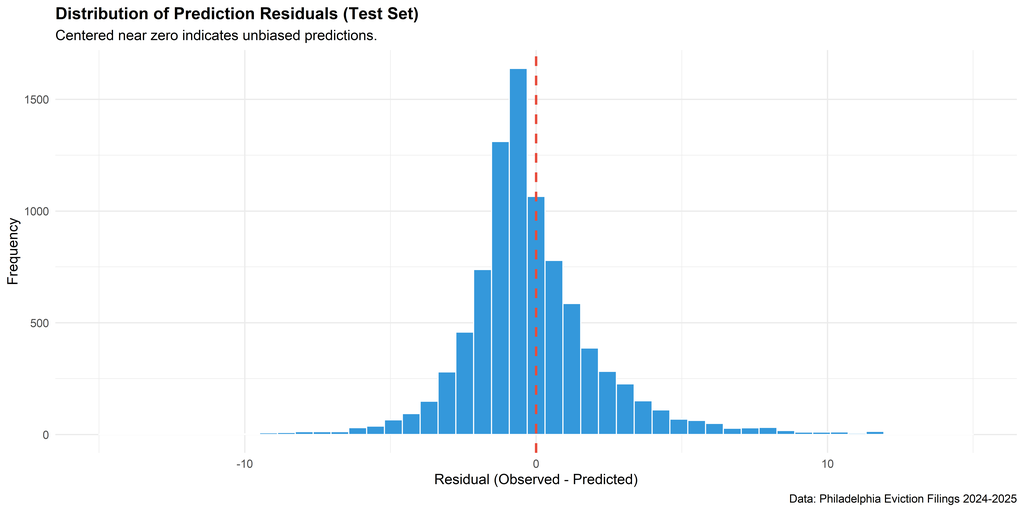

```r
# Create residual distribution plot.
residual_plot <- df_test_pred %>%
  ggplot(aes(x = residual)) +
  geom_histogram(bins = 50, fill = "#3498DB", color = "white", alpha = 1) +
  geom_vline(xintercept = 0, linetype = "dashed", color = "#E74C3C", linewidth = 1) +
  scale_x_continuous(limits = c(-15, 15)) +
  labs(
    title = "Distribution of Prediction Residuals (Test Set)",
    subtitle = "Centered near zero indicates unbiased predictions.",
    x = "Residual (Observed - Predicted)",
    y = "Frequency",
    caption = "Data: Philadelphia Eviction Filings 2024-2025"
  ) +
  theme_minimal(base_size = 12) +
  theme(plot.title = element_text(face = "bold", size = 14))

# Display residual plot.
residual_plot
```

## 5. RISK CLASSIFICATION SYSTEM

### Creating Risk Quintiles

```r
# Create risk quintile classification based on predicted values.
df_test_risk <- df_test_pred %>%
  mutate(
    risk_quintile = ntile(predicted, 5),
    risk_category = case_when(
      risk_quintile == 1 ~ "Lowest Risk",
      risk_quintile == 2 ~ "Low Risk",
      risk_quintile == 3 ~ "Moderate Risk",
      risk_quintile == 4 ~ "High Risk",
      risk_quintile == 5 ~ "Highest Risk"
    ),
    risk_category = factor(risk_category,
                          levels = c("Lowest Risk", "Low Risk", "Moderate Risk",
                                    "High Risk", "Highest Risk"))
  )

# Calculate observed filings by risk category.
risk_validation <- df_test_risk %>%
  group_by(risk_category) %>%
  summarize(
    n_tract_months = n(),
    mean_observed = mean(filings_count, na.rm = TRUE),
    median_observed = median(filings_count, na.rm = TRUE),
    total_filings = sum(filings_count, na.rm = TRUE),
    .groups = "drop"
  ) %>%
  mutate(pct_total_filings = total_filings / sum(total_filings) * 100)

# Display risk validation table.
risk_validation %>%
  kable(digits = 2, caption = "Observed Filings by Predicted Risk Category",
        col.names = c("Risk Category", "Observations", "Mean Observed", "Median Observed", "Filings", "% Filings")) %>%
  kable_styling(bootstrap_options = c("striped", "hover"))
```

Observed Filings by Predicted Risk Category

| Risk Category | Observations | Mean Observed | Median Observed | Filings | % Filings |
| --- | --- | --- | --- | --- | --- |
| Lowest Risk | 1767 | 0.66 | 0 | 1169 | 5.02 |
| Low Risk | 1767 | 1.27 | 1 | 2251 | 9.66 |
| Moderate Risk | 1766 | 2.18 | 2 | 3854 | 16.54 |
| High Risk | 1766 | 3.26 | 3 | 5761 | 24.73 |
| Highest Risk | 1766 | 5.81 | 5 | 10263 | 44.05 |

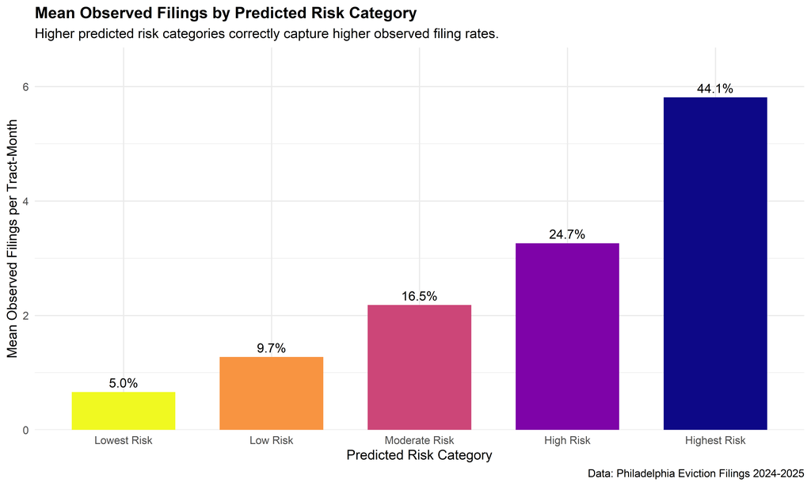

```r
# Create bar plot showing observed filings by risk category.
risk_bar_plot <- risk_validation %>%
  ggplot(aes(x = risk_category, y = mean_observed, fill = risk_category)) +
  geom_col(width = 0.7) +
  geom_text(aes(label = sprintf("%.1f%%", pct_total_filings)),
            vjust = -0.5, size = 4) +
  scale_fill_viridis_d(option = "plasma", direction = -1) +
  scale_y_continuous(labels = comma, expand = expansion(mult = c(0, 0.15))) +
  labs(
    title = "Mean Observed Filings by Predicted Risk Category",
    subtitle = "Higher predicted risk categories correctly capture higher observed filing rates.",
    x = "Predicted Risk Category",
    y = "Mean Observed Filings per Tract-Month",
    caption = "Data: Philadelphia Eviction Filings 2024-2025"
  ) +
  theme_minimal(base_size = 12) +
  theme(
    plot.title = element_text(face = "bold", size = 14),
    axis.text.x = element_text(angle = 0, hjust = 0.5),
    legend.position = "none"
  )

# Display risk bar plot.
risk_bar_plot
```

### High-Risk Tract Profile

```r
# Profile characteristics of highest risk tract-months.
high_risk_profile <- df_test_risk %>%
  filter(risk_category == "Highest Risk") %>%
  group_by(racial_majority) %>%
  summarize(
    n_tract_months = n(),
    pct_of_high_risk = n() / nrow(df_test_risk %>% filter(risk_category == "Highest Risk")) * 100,
    mean_filings = mean(filings_count, na.rm = TRUE),
    .groups = "drop"
  ) %>%
  arrange(desc(n_tract_months))

high_risk_profile %>%
  kable(digits = 1, caption = "Racial Composition of Highest Risk Tract-Months",
        col.names = c("Racial Majority", "Observations", "% High Risk", "Mean Filings")) %>%
  kable_styling(bootstrap_options = c("striped", "hover"))
```

Racial Composition of Highest Risk Tract-Months

| Racial Majority | Observations | % High Risk | Mean Filings |
| --- | --- | --- | --- |
| Black | 1191 | 67.4 | 5.7 |
| Other | 341 | 19.3 | 5.3 |
| White | 148 | 8.4 | 8.9 |
| Hispanic | 86 | 4.9 | 4.2 |

## 6. MODEL INTERPRETATION

### Feature Importance

```r
# Get standardized coefficients for interpretation.
feature_importance <- tidy(model_nb_3) %>%
  filter(term != "(Intercept)") %>%
  mutate(
    abs_estimate = abs(estimate),
    direction = ifelse(estimate > 0, "Positive", "Negative"),
    category = case_when(
      str_detect(term, "filings_") ~ "Temporal",
      str_detect(term, "spatial_lag_filings") ~ "Spatial",
      str_detect(term, "log_avg_balance") ~ "Tax Delinquency",
      str_detect(term, "pct_renter") |
        str_detect(term, "poverty_rate") |
        str_detect(term, "severe_rent_burden") |
        str_detect(term, "unemployment_rate") |
        str_detect(term, "log_median_income") |
        str_detect(term, "pct_single_mother") ~ "Socioeconomic (ACS)",
      str_detect(term, "factor\\(month_num\\)") ~ "Seasonality",
      str_detect(term, "moratorium") ~ "Policy",
      str_detect(term, "factor\\(racial_majority\\)") ~ "Demographic",
      str_detect(term, "neighborhood") ~ "Neighborhood",
      TRUE ~ "Other"
    )
  ) %>%
  arrange(desc(abs_estimate)) %>%
  head(10)

# Create feature importance plot.
importance_plot <- feature_importance %>%
  ggplot(aes(x = reorder(term, abs_estimate), y = estimate, fill = category)) +
  geom_col(width = 0.7) +
  coord_flip() +
  scale_fill_brewer(palette = "Set2") +
  labs(
    title = "Top 10 Most Important Predictors",
    subtitle = "Coefficient magnitude indicates effect size on log(expected filings).",
    x = "Predictor Variable",
    y = "Coefficient Estimate",
    fill = "Category",
    caption = "Negative Binomial Regression Coefficients"
  ) +
  theme_minimal(base_size = 12) +
  theme(
    plot.title = element_text(face = "bold", size = 14),
    legend.position = "bottom"
  )

# Display importance plot.
importance_plot
```

[figure not shown]

```r
# Get standardized coefficients for interpretation.
all_coefficients <- tidy(model_nb_3) %>%
  # Remove intercept term.
  filter(term != "(Intercept)") %>%
  # Filter out terms with "neighborhood".
  filter(!str_detect(term, "neighborhood")) %>%
  mutate(
    abs_estimate = abs(estimate),
    direction = ifelse(estimate > 0, "Positive", "Negative"),
    category = case_when(
      str_detect(term, "filings_") ~ "Temporal",
      str_detect(term, "spatial_lag_filings") ~ "Spatial",
      str_detect(term, "log_avg_balance") ~ "Tax Delinquency",
      str_detect(term, "pct_renter") |
        str_detect(term, "poverty_rate") |
        str_detect(term, "severe_rent_burden") |
        str_detect(term, "unemployment_rate") |
        str_detect(term, "log_median_income") |
        str_detect(term, "pct_single_mother") ~ "Socioeconomic (ACS)",
      str_detect(term, "factor\\(month_num\\)") ~ "Seasonality",
      str_detect(term, "moratorium") ~ "Policy",
      str_detect(term, "factor\\(racial_majority\\)") ~ "Demographic",
      TRUE ~ "Other"
    )
  ) %>%
  arrange(desc(abs_estimate)) %>%
  head(10)

# Create feature importance plot.
other_importance_plot <- all_coefficients %>%
  ggplot(aes(x = reorder(term, abs_estimate), y = estimate, fill = category)) +
  geom_col(width = 0.7) +
  coord_flip() +
  scale_fill_brewer(palette = "Set2") +
  labs(
    title = "All Non-Neighborhood Predictors",
    subtitle = "Coefficient magnitude indicates effect size on log(expected filings).",
    x = "Predictor Variable",
    y = "Coefficient Estimate",
    fill = "Category"
  ) +
  theme_minimal(base_size = 12) +
  theme(
    plot.title = element_text(face = "bold", size = 14),
    legend.position = "bottom"
  )

# Display importance plot.
other_importance_plot
```

[figure not shown]

```r
# Specifically analyze contribution of ACS features.
acs_contribution <- tidy(model_nb_3) %>%
  filter(str_detect(term, "pct_renter|poverty_rate|severe_rent_burden|unemployment_rate")) %>%
  mutate(
    irr = exp(estimate),
    pct_change = (irr - 1) * 100,
    significant = ifelse(p.value < 0.05, "Yes", "No")
  )%>%
  rename(standard_error = std.error, p_value = p.value, percent_change = pct_change) %>%
  select(term, estimate, standard_error, p_value, irr, percent_change, significant)

acs_contribution %>%
  kable(digits = 3, caption = "ACS Socioeconomic Feature Effects",
        col.names = c("Term", "Estimate", "Standard Error", "P-Value", "IRR", "% Change", "Significant")) %>%
  kable_styling(bootstrap_options = c("striped", "hover"))
```

ACS Socioeconomic Feature Effects

| Term | Estimate | Standard Error | P-Value | IRR | % Change | Significant |
| --- | --- | --- | --- | --- | --- | --- |
| pct_renter | 0.017 | 0.001 | 0.000 | 1.017 | 1.672 | Yes |
| severe_rent_burden | 0.001 | 0.001 | 0.050 | 1.001 | 0.135 | No |
| poverty_rate | -0.004 | 0.001 | 0.001 | 0.996 | -0.390 | Yes |

### Incidence Rate Ratios

```r
# Calculate incidence rate ratios for interpretation.
irr_table <- tidy(model_nb_3) %>%
  mutate(
    irr = exp(estimate),
    # 1.96 is z-score for 95% confidence level.
    irr_lower = exp(estimate - 1.96 * std.error),
    irr_upper = exp(estimate + 1.96 * std.error),
    pct_change = (irr - 1) * 100
  ) %>%
  filter(term != "(Intercept)") %>%
  rename(p_value = p.value) %>%
  select(term, irr, irr_lower, irr_upper, pct_change, p_value)

irr_table %>%
  head(15) %>%
  kable(digits = 3, caption = "Incidence Rate Ratios (IRR) for Key Predictors",
        col.names = c("Term", "IRR", "IRR Lower Confidence", "IRR Upper Confidence", "% Change", "P-Value")) %>%
  kable_styling(bootstrap_options = c("striped", "hover"))
```

Incidence Rate Ratios (IRR) for Key Predictors

| Term | IRR | IRR Lower Confidence | IRR Upper Confidence | % Change | P-Value |
| --- | --- | --- | --- | --- | --- |
| filings_ma3 | 1.114 | 1.107 | 1.121 | 11.432 | 0.000 |
| moratorium_active | 0.483 | 0.464 | 0.502 | -51.732 | 0.000 |
| factor(month_num)2 | 0.769 | 0.709 | 0.834 | -23.086 | 0.000 |
| factor(month_num)3 | 1.050 | 0.971 | 1.136 | 5.018 | 0.222 |
| factor(month_num)4 | 0.512 | 0.472 | 0.555 | -48.830 | 0.000 |
| factor(month_num)5 | 0.663 | 0.612 | 0.719 | -33.654 | 0.000 |
| factor(month_num)6 | 0.717 | 0.662 | 0.776 | -28.344 | 0.000 |
| factor(month_num)7 | 0.833 | 0.770 | 0.900 | -16.747 | 0.000 |
| factor(month_num)8 | 0.985 | 0.913 | 1.063 | -1.458 | 0.704 |
| factor(month_num)9 | 1.084 | 1.006 | 1.168 | 8.369 | 0.035 |
| factor(month_num)10 | 0.999 | 0.928 | 1.076 | -0.069 | 0.985 |
| factor(month_num)11 | 0.866 | 0.804 | 0.932 | -13.442 | 0.000 |
| factor(month_num)12 | 0.917 | 0.852 | 0.988 | -8.256 | 0.022 |
| is_extreme_spike | 5.808 | 4.681 | 7.205 | 480.753 | 0.000 |
| neighborhoodAcademy Gardens | 1.598 | 1.173 | 2.176 | 59.789 | 0.003 |

`filings_ma3`: For every one-unit increase in the 3-month moving average of past eviction filings, the expected number of current eviction filings increases by a factor of 1.114 or 11.4%. So a history of higher recent filings strongly predicts higher current filings.

`moratorium_active`: When an eviction moratorium is active the expected number of eviction filings is multiplied by 0.483 or is 51.7% lower compared to when the moratorium is not active.

`is_extreme_spike`: If a time period is classified as having an extreme spike in filings, the expected number of eviction filings is nearly six times higher multiplied by 5.808, or increases by a staggering 481%, compared to a period without a spike.

`neighborhoodAcademy Gardens`: Compared to the baseline East Falls neighborhood, Academy Gardens is expected to have 59.8% more eviction filings.

```r
# Create actionable output for city agencies with intervention thresholds.
operational_output <- df_test_pred %>%
  filter(predicted >= 5) %>%
  group_by(GEOID) %>%
  summarize(
    predicted_filings_next_month = mean(predicted),
    n_high_risk_months = n(),
    .groups = "drop"
  ) %>%
  left_join(df_acs, by = "GEOID") %>%
  arrange(desc(predicted_filings_next_month))

operational_output
```

```
# A tibble: 107 × 16
   GEOID       predicted_filings_nex…¹ n_high_risk_months pct_renter median_rent
   <chr>                         <dbl>              <int>      <dbl>       <dbl>
 1 42101021800                   23.7                  21       71.3        1558
 2 42101030100                   17.0                  21       45.5         749
 3 42101025200                   14.3                  22       57.6         879
 4 42101036100                   12.8                  17       26.7        1639
 5 42101015200                   10.7                  22       68.3         961
 6 42101025700                   10.5                   4       71.5        1737
 7 42101024000                   10.5                  22       72.2        1098
 8 42101023900                    9.78                 22       92.7        1500
 9 42101037700                    9.73                 15       85.9        1159
10 42101008500                    9.45                 23       64.2        1028
# ℹ 97 more rows
# ℹ abbreviated name: ¹predicted_filings_next_month
# ℹ 11 more variables: rent_burden_pct <dbl>, median_income <dbl>,
#   log_median_income <dbl>, poverty_rate <dbl>, unemployment_rate <dbl>,
#   pct_college <dbl>, total_pop <dbl>, log_pop <dbl>, median_age <dbl>,
#   pct_single_mother <dbl>, severe_rent_burden <dbl>
```

# III. EQUITY ASSESSMENT

## 1. Impact Analysis

```r
# Calculate prediction errors by racial majority to assess disparate impact.
equity_metrics <- df_test_pred %>%
  filter(!is.na(racial_majority), racial_majority != "") %>%
  group_by(racial_majority) %>%
  summarize(
    n_obs = n(),
    mean_observed = mean(filings_count, na.rm = TRUE),
    mean_predicted = mean(predicted, na.rm = TRUE),
    mae = mean(abs_error, na.rm = TRUE),
    mean_error = mean(residual, na.rm = TRUE),
    under_prediction_rate = sum(residual > 0) / n() * 100,
    .groups = "drop"
  )

# Display equity metrics table.
equity_metrics %>%
  kable(digits = 2, caption = "Model Performance Metrics by Tract Racial Majority",
        col.names = c("Racial Majority", "Observations", "Mean Observed", "Mean Predicted", "MAE", "Mean Error", "Under-Prediction Rate")) %>%
  kable_styling(bootstrap_options = c("striped", "hover"))
```

Model Performance Metrics by Tract Racial Majority

| Racial Majority | Observations | Mean Observed | Mean Predicted | MAE | Mean Error | Under-Prediction Rate |
| --- | --- | --- | --- | --- | --- | --- |
| Black | 3289 | 3.63 | 3.94 | 2.22 | -0.31 | 39.68 |
| Hispanic | 529 | 2.51 | 2.77 | 1.57 | -0.27 | 41.59 |
| Other | 1656 | 2.77 | 3.07 | 1.86 | -0.30 | 36.78 |
| White | 3358 | 1.62 | 1.65 | 1.31 | -0.03 | 37.25 |

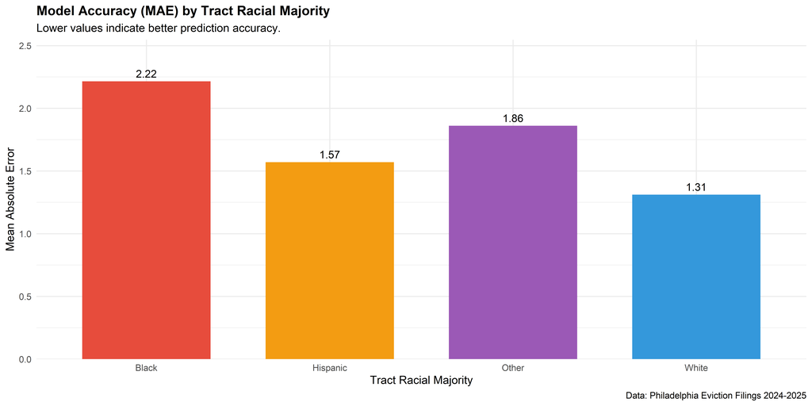

```r
# Create plot comparing MAE across racial categories.
equity_plot <- equity_metrics %>%
  ggplot(aes(x = racial_majority, y = mae, fill = racial_majority)) +
  geom_col(width = 0.7) +
  geom_text(aes(label = sprintf("%.2f", mae)), vjust = -0.5, size = 4) +
  scale_fill_manual(values = racial_colors) +
  scale_y_continuous(expand = expansion(mult = c(0, 0.15))) +
  labs(
    title = "Model Accuracy (MAE) by Tract Racial Majority",
    subtitle = "Lower values indicate better prediction accuracy.",
    x = "Tract Racial Majority",
    y = "Mean Absolute Error",
    caption = "Data: Philadelphia Eviction Filings 2024-2025"
  ) +
  theme_minimal(base_size = 12) +
  theme(
    plot.title = element_text(face = "bold", size = 14),
    legend.position = "none"
  )

# Display equity plot.
equity_plot
```

## 2. Prediction Calibration by Race

```r
# Create calibration plot showing predicted vs observed by racial majority.
calibration_plot <- df_test_pred %>%
  filter(!is.na(racial_majority), racial_majority != "") %>%
  mutate(predicted_bin = cut(predicted, breaks = seq(0, 15, by = 1), include.lowest = TRUE)) %>%
  filter(!is.na(predicted_bin)) %>%
  group_by(racial_majority, predicted_bin) %>%
  summarize(
    mean_predicted = mean(predicted, na.rm = TRUE),
    mean_observed = mean(filings_count, na.rm = TRUE),
    n = n(),
    .groups = "drop"
  ) %>%
  filter(n >= 10) %>%
  ggplot(aes(x = mean_predicted, y = mean_observed, color = racial_majority)) +
  geom_point(aes(size = n), alpha = 0.75) +
  geom_abline(intercept = 0, slope = 1, linetype = "dashed", color = "black") +
  scale_color_manual(values = racial_colors) +
  scale_size_continuous(range = c(2, 8)) +
  labs(
    title = "Model by Tract Racial Majority",
    subtitle = "Points on diagonal indicate good predictions.",
    x = "Mean Predicted Filings",
    y = "Mean Observed Filings",
    color = "Racial\nMajority",
    size = "Observations",
    caption = "Data: Philadelphia Eviction Filings 2024-2025"
  ) +
  theme_minimal(base_size = 12) +
  theme(
    plot.title = element_text(face = "bold", size = 14),
    legend.position = "right"
  )

# Display calibration plot.
calibration_plot
```

[figure not shown]

## 3. Risk Category Distribution by Race

```r
# Calculate risk category distribution by racial majority.
risk_by_race <- df_test_risk %>%
  filter(!is.na(racial_majority), racial_majority != "") %>%
  group_by(racial_majority, risk_category) %>%
  summarize(n = n(), .groups = "drop") %>%
  group_by(racial_majority) %>%
  mutate(pct = n / sum(n) * 100) %>%
  ungroup()

# Create stacked bar plot.
risk_race_plot <- risk_by_race %>%
  ggplot(aes(x = racial_majority, y = pct, fill = risk_category)) +
  geom_col(width = 0.7) +
  scale_fill_viridis_d(option = "plasma", direction = -1) +
  scale_y_continuous(labels = percent_format(scale = 1)) +
  labs(
    title = "Risk Distribution by Tract Racial Majority",
    subtitle = "Black-majority tracts classified as high risk.",
    x = "Tract Racial Majority",
    y = "Percentage of Tract-Months",
    fill = "Risk\nCategory",
    caption = "Data: Philadelphia Eviction Filings 2024-2025"
  ) +
  theme_minimal(base_size = 12) +
  theme(
    plot.title = element_text(face = "bold", size = 14),
    legend.position = "right"
  )

# Display risk by race plot.
risk_race_plot
```

[figure not shown]

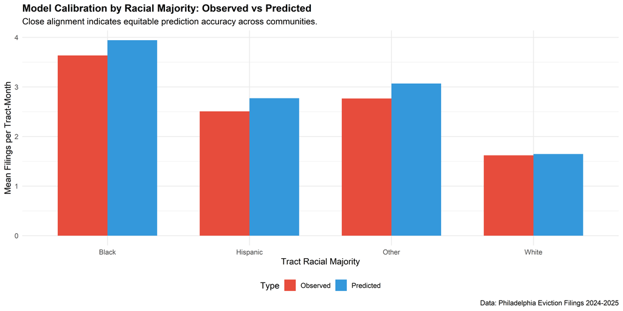

```r
# Create equity comparison plot.
equity_plot <- equity_metrics %>%
  pivot_longer(cols = c(mean_observed, mean_predicted),
               names_to = "type", values_to = "value") %>%
  mutate(type = ifelse(type == "mean_observed", "Observed", "Predicted")) %>%
  ggplot(aes(x = racial_majority, y = value, fill = type)) +
  geom_col(position = "dodge", width = 0.7) +
  scale_fill_manual(values = c("Observed" = "#E74C3C", "Predicted" = "#3498DB")) +
  labs(
    title = "Model Calibration by Racial Majority: Observed vs Predicted",
    subtitle = "Close alignment indicates equitable prediction accuracy across communities.",
    x = "Tract Racial Majority",
    y = "Mean Filings per Tract-Month",
    fill = "Type",
    caption = "Data: Philadelphia Eviction Filings 2024-2025"
  ) +
  theme_minimal(base_size = 12) +
  theme(
    plot.title = element_text(face = "bold", size = 14),
    legend.position = "bottom"
  )

# Display equity plot.
equity_plot
```

# AI USAGE

**Free version of Claude Sonnet 4.5 used for debugging code, especially the final panel data portion.**

Several code chunks provided by Dr. Delmelle with adjustments from previous labs and lectures.